# Visualizing Growth Using World Bank Development Indicators

Sean McSkeane, Albert Chu, Sonny Liu

[figure not shown]

1. Background
   - Introduction
   - Defintions
   - Libraries
   - Context
- Data Processing
  - Data Collection
  - Creation of GDP Data
  - Creation of Miscellaneous Data
- Exploratory Analysis and Data Visualization
  - GDP Statistics
  - GDP Box Plots
  - Observations
  - Miscellaneous Joint Plots
  - Observations
- Analysis, Hypothesis Testing, and Machine Learning
  - Linear Regression
- Insight and Policy Design
  - Summary
  - Insight

## Background

### 1.0 Introduction

Economists are constantly making predictions about world economies with economic models and forecasts. In this analysis, we attempt to correlate the percentage growth of GDP per capita for nations using data provided by the World Bank. The World Bank is an international financial institution based in Washington D.C. that provides loans and grants to the governments of poorer countries for the purpose of pursuing capital projects. One of the major goals of the World Bank is to end extreme poverty in developing nations.

We use data provided from the [World Bank's World Development Indicators](https://databank.worldbank.org/source/world-development-indicators) to create our own custom comma-separated values (CSV) file for our own data analysis. According to the World Bank's website, "World Development Indicators (WDI) is the primary World Bank collection of development indicators, compiled from officially recognized international sources. It presents the most current and accurate global development data available, and includes national, regional and global estimates."

In our analysis we visualize the growth of world economies by cleaning and reorganizing, plotting important economic factors across time, correlating other factors with gdp per capita, and using machine learning to predict future growth.

### 1.1 Definitions

Here are definitions of the datapoints we use directly taken from the [World Bank.](https://databank.worldbank.org/metadataglossary/world-development-indicators/series)

GDP:

> GDP stands for gross domestic product. It is used to measure the market value of all the final goods and services produced in a specific time period.

Per Capita:

> Per capita simply is an economic term that means per person in a specefied area.

Final Consumption Expenditure:

> Final consumption expenditure (formerly total consumption) is the sum of household final consumption expenditure (private consumption) and general government final consumption expenditure (general government consumption). This estimate includes any statistical discrepancy in the use of resources relative to the supply of resources.

General government final consumption expenditure (current US$):

> General government final consumption expenditure (formerly general government consumption) includes all government current expenditures for purchases of goods and services (including compensation of employees). It also includes most expenditures on national defense and security, but excludes government military expenditures that are part of government capital formation. Data are in current U.S. dollars.

Foreign direct investment, net inflows (BoP, current US$):

> Foreign direct investment refers to direct investment equity flows in the reporting economy. It is the sum of equity capital, reinvestment of earnings, and other capital. Direct investment is a category of cross-border investment associated with a resident in one economy having control or a significant degree of influence on the management of an enterprise that is resident in another economy. Ownership of 10 percent or more of the ordinary shares of voting stock is the criterion for determining the existence of a direct investment relationship. Data are in current U.S. dollars.

Exports of goods and services (current US$):

> Exports of goods and services comprise all transactions between residents of a country and the rest of the world involving a change of ownership from residents to nonresidents of general merchandise, net exports of goods under merchanting, nonmonetary gold, and services. Data are in current U.S. dollars.

Imports of goods and services (current US$):

> Imports of goods and services comprise all transactions between residents of a country and the rest of the world involving a change of ownership from nonresidents to residents of general merchandise, nonmonetary gold, and services. Data are in current U.S. dollars.

### 1.2 Libraries

The following python libraries used are listed below along with their official descriptions:

- pandas - an open source, BSD-licensed library providing high-performance, easy-to-use data structures and data analysis tools for the Python programming language ([docs](https://pandas.pydata.org/))
- numpy - NumPy is the fundamental package for scientific computing with Python ([docs](https://numpy.org/))
- matplotlib - Matplotlib is a Python 2D plotting library which produces publication quality figures in a variety of hardcopy formats and interactive environments across platforms ([docs](https://matplotlib.org/))
- seaborn - Seaborn is a Python data visualization library based on matplotlib. It provides a high-level interface for drawing attractive and informative statistical graphics ([docs](https://seaborn.pydata.org/))
- sklearn - Scikit-learn is an open source machine learning library that supports supervised and unsupervised learning. It also provides various tools for model fitting, data preprocessing, model selection and evaluation, and many other utilities ([docs](https://scikit-learn.org/stable/))
- statsmodels - is a Python module that provides classes and functions for the estimation of many different statistical models, as well as for conducting statistical tests, and statistical data exploration ([docs](https://www.statsmodels.org/stable/index.html))
- folium - makes it easy to visualize data that’s been manipulated in Python on an interactive leaflet map. ([docs](https://python-visualization.github.io/folium/))

```python
import pandas as pd
from pandas.io.json import json_normalize
import numpy as np
import matplotlib.pyplot as plt
import seaborn as sns
from sklearn import linear_model
from sklearn.preprocessing import PolynomialFeatures
from sklearn import model_selection
from statsmodels import api as sm
import folium
import json
```

### 1.3 Context

According to [investopedia](https://www.investopedia.com/terms/e/economic-forecasting.asp), "Economic forecasting is the process of attempting to predict the future condition of the economy using a combination of important and widely followed indicators. Economic forecasting involves the building of statistical models with inputs of several key variables, or indicators, typically in an attempt to come up with a future gross domestic product (GDP) growth rate. Primary economic indicators include inflation, interest rates, industrial production, consumer confidence, worker productivity, retail sales, and unemployment rates."

Economic predicitons are incredibly important for buisnesses and governments world wide. They want to manage their finances accoridingly so that they can encourage growth and mitigate losses. However, many descriped economic forecasting as unreliable. Investopedia goes on to even state that "Economic forecasting is often described as a flawed science." According to [Bloomberg Buisness](https://www.bloomberg.com/news/articles/2019-03-28/economists-are-actually-terrible-at-forecasting-recessions), "A recent working [paper](https://www.imf.org/en/Publications/WP/Issues/2018/03/05/How-Well-Do-Economists-Forecast-Recessions-45672) by Zidong An, Joao Tovar Jalles, and Prakash Loungani discovered that of 153 recessions in 63 countries from 1992 to 2014, only five were predicted by a consensus of private-sector economists in April of the preceding year." This shows that economies are far too complex for even large agencies to forecast accurately, and that economic models are often misleading.

[figure not shown]

source from [Bloomberg Buisness](https://www.bloomberg.com/news/articles/2019-03-28/economists-are-actually-terrible-at-forecasting-recessions)

In this project, we attempt to correlate GDP growth with several important key data points. This project will help us to get an intuition at the challenges economists face and also to see how far data science and programming can help amateurs like ourselves tackle on national economies.

## Data Processing

### 2.0 Data Collection

The formula for calculating GDP is:

```
GDP = Consumption + Investment + Government Spending + Net Exports
```

therefore we concluded it would be best if we split the CSV into two dataframes which included GDP calculators and another dataframe from more miscellenous data.

We searched through the World Bank Development Indicators in order to find datapoints that matched the formula as close as possible. We also chose datapoints that we found interesting and/or could possibly have a correlation with GDP per capita and GDP growth. Our datset is availble [here](https://github.com/thechuster/thechuster.github.io/blob/albert/WorldBankData/data.csv) at the project's github page.

```python
worldBankDevInc = pd.read_csv("WorldBankData/data.csv")

worldBankDevInc.dropna(inplace=True)
countryName = ""
first = True
newRows = []
countriesData = []

for index, row in worldBankDevInc.iterrows():
    if (countryName != row["Country Name"]):
        if (first == False):
            countriesData.append(df)
        countryName = row["Country Name"]
        df = pd.DataFrame(columns=worldBankDevInc.columns)
        first = False

    df = df.append(row, ignore_index=True)

worldData = pd.concat(countriesData)
with pd.option_context('display.max_rows', None, 'display.max_columns', None):
    display(df)
    display(countriesData[206])
```

|  | Country Name | Country Code | Series Name | Series Code | 1960 [YR1960] | 1961 [YR1961] | 1962 [YR1962] | 1963 [YR1963] | 1964 [YR1964] | 1965 [YR1965] | 1966 [YR1966] | 1967 [YR1967] | 1968 [YR1968] | 1969 [YR1969] | 1970 [YR1970] | 1971 [YR1971] | 1972 [YR1972] | 1973 [YR1973] | 1974 [YR1974] | 1975 [YR1975] | 1976 [YR1976] | 1977 [YR1977] | 1978 [YR1978] | 1979 [YR1979] | 1980 [YR1980] | 1981 [YR1981] | 1982 [YR1982] | 1983 [YR1983] | 1984 [YR1984] | … |
| --- | --- | --- | --- | --- | --- | --- | --- | --- | --- | --- | --- | --- | --- | --- | --- | --- | --- | --- | --- | --- | --- | --- | --- | --- | --- | --- | --- | --- | --- | --- |
| 0 | World | WLD | Adjusted net enrollment rate, primary (% of pr... | SE.PRM.TENR | .. | .. | .. | .. | .. | .. | .. | .. | .. | .. | .. | .. | .. | .. | .. | .. | .. | .. | .. | .. | .. | .. | .. | .. | .. | … |
| 1 | World | WLD | Adjusted net national income (annual % growth) | NY.ADJ.NNTY.KD.ZG | .. | .. | .. | .. | .. | .. | .. | .. | .. | .. | .. | 3.82455669177821 | 5.53180688564998 | 6.29191447750782 | -1.36409149911428 | 0.775066291042961 | 4.87383091854163 | 3.75054299401589 | 4.63630589579466 | 1.79554937138471 | 0.517066830716701 | 1.86491290260848 | 0.805927335815127 | 3.56140417297873 | 5.97931692584852 | … |
| 2 | World | WLD | Adjusted net national income (current US$) | NY.ADJ.NNTY.CD | .. | .. | .. | .. | .. | .. | .. | .. | .. | .. | .. | .. | .. | .. | .. | .. | .. | .. | .. | .. | .. | .. | .. | .. | .. | … |
| 3 | World | WLD | Current health expenditure (% of GDP) | SH.XPD.CHEX.GD.ZS | .. | .. | .. | .. | .. | .. | .. | .. | .. | .. | .. | .. | .. | .. | .. | .. | .. | .. | .. | .. | .. | .. | .. | .. | .. | … |
| 4 | World | WLD | Employment in agriculture (% of total employme... | SL.AGR.EMPL.ZS | .. | .. | .. | .. | .. | .. | .. | .. | .. | .. | .. | .. | .. | .. | .. | .. | .. | .. | .. | .. | .. | .. | .. | .. | .. | … |
| 5 | World | WLD | Employment in industry (% of total employment)... | SL.IND.EMPL.ZS | .. | .. | .. | .. | .. | .. | .. | .. | .. | .. | .. | .. | .. | .. | .. | .. | .. | .. | .. | .. | .. | .. | .. | .. | .. | … |
| 6 | World | WLD | Employment in services (% of total employment)... | SL.SRV.EMPL.ZS | .. | .. | .. | .. | .. | .. | .. | .. | .. | .. | .. | .. | .. | .. | .. | .. | .. | .. | .. | .. | .. | .. | .. | .. | .. | … |
| 7 | World | WLD | Fertility rate, total (births per woman) | SP.DYN.TFRT.IN | 4.979307108885 | 5.00191978243415 | 5.02367146408933 | 5.04400040674044 | 5.05490891301623 | 5.03915577395467 | 4.99038258536087 | 4.97200862168929 | 4.92216247187193 | 4.85457238196183 | 4.77740726096387 | 4.66896402144656 | 4.53943728246075 | 4.41068383450602 | 4.2885892504327 | 4.15651327744316 | 4.04028538038847 | 3.93667877523915 | 3.84304686755108 | 3.77341369166979 | 3.71365928624454 | 3.65661971173965 | 3.62717669004806 | 3.59460070199888 | 3.56423664936055 | … |
| 8 | World | WLD | GDP (current US$) | NY.GDP.MKTP.CD | 1370773175299.13 | 1428243252162.75 | 1533428552164.23 | 1651254441090.99 | 1809566507676.47 | 1970263431689.46 | 2137443239818.92 | 2274766100844.97 | 2454039687169.93 | 2702384325609.14 | 2967134190513.09 | 3277473529735.25 | 3780008408344.25 | 4607296495839.12 | 5313811666230.22 | 5916138399186.38 | 6436618979871.82 | 7280008873683.09 | 8570950836042.56 | 9958993254911.54 | 11219651208332.4 | 11616548460676.7 | 11507419044047.1 | 11739581031767.4 | 12172632270220 | … |
| 9 | World | WLD | GDP growth (annual %) | NY.GDP.MKTP.KD.ZG | .. | 4.35975840188152 | 5.57589783213135 | 5.21735787229068 | 6.66471427898958 | 5.55901953472871 | 5.80277687909742 | 4.41418708917081 | 6.17799506138148 | 6.10989424564778 | 3.67551350685402 | 4.34201723410811 | 5.72561854441467 | 6.50688060060303 | 1.9981787361673 | 0.604285401850291 | 5.27355851107041 | 3.93272228011419 | 3.8893477766391 | 4.12280723200655 | 1.90410244952017 | 1.92649516152991 | 0.423561268331966 | 2.4136211184212 | 4.50889380516037 | … |
| 10 | World | WLD | GDP per capita growth (annual %) | NY.GDP.PCAP.KD.ZG | .. | 2.96546892976448 | 3.78632332497055 | 3.07027760261226 | 4.51897302590693 | 3.43351075792553 | 3.61808616431915 | 2.32032213633795 | 4.06289294488624 | 3.9131603865597 | 1.55227279684919 | 2.18847110725366 | 3.62034603454364 | 4.45220500206499 | 0.0507848306460517 | -1.23810561170468 | 3.42618857153256 | 2.14540104013507 | 2.10453136582056 | 2.31999386406363 | 0.152197781559167 | 0.158993962531014 | -1.35133746366949 | 0.619313810035919 | 2.71551344351812 | … |
| 11 | World | WLD | GDP per capita (current US$) | NY.GDP.PCAP.CD | 452.078267432285 | 464.738604766151 | 490.507281173762 | 517.418513114129 | 555.618724989832 | 592.778630064154 | 629.79808078489 | 656.819251902104 | 694.467750526003 | 748.914578702572 | 805.444855484229 | 871.325880387674 | 984.915582987193 | 1177.31341532866 | 1331.92642810845 | 1455.7455597655 | 1556.02307058378 | 1729.64372793428 | 2001.37168286414 | 2285.22514552985 | 2530.24050329355 | 2575.28677134525 | 2506.03680451145 | 2511.135314347 | 2561.08948864476 | … |
| 12 | World | WLD | Government expenditure on education, total (% ... | SE.XPD.TOTL.GD.ZS | .. | .. | .. | .. | .. | .. | .. | .. | .. | .. | .. | .. | .. | .. | .. | .. | .. | .. | .. | .. | .. | .. | .. | .. | .. | … |
| 13 | World | WLD | GNI (current US$) | NY.GNP.MKTP.CD | 1353201911072.14 | 1417375790025.72 | 1520733738365.07 | 1633855186714.56 | 1801174449952.18 | 1965325698282.86 | 2125600754198.07 | 2264821962966.59 | 2464392605896.97 | 2715332449292.85 | 2968862882540.16 | 3280123305001.94 | 3793070841579 | 4631644194748.78 | 5330145416165.49 | 5937950669651.34 | 6445729552599.81 | 7280068184932.13 | 8589426525716.66 | 9950827901034.49 | 11175370543105.5 | 11546813843369.9 | 11454299548757.5 | 11656570082242 | 12105839612460 | … |
| 14 | World | WLD | GNI growth (annual %) | NY.GNP.MKTP.KD.ZG | .. | .. | .. | .. | .. | .. | .. | .. | .. | .. | .. | 3.94149304567881 | 5.52178878023415 | 6.42545144666747 | 1.57121823878535 | 0.404048103001259 | 4.84788225551087 | 3.84975341098625 | 4.2322850532523 | 4.04868678753884 | 1.46980193646533 | 1.63016183183737 | 0.373537986546665 | 2.53714143475625 | 4.35788086446817 | … |
| 15 | World | WLD | GINI index (World Bank estimate) | SI.POV.GINI | .. | .. | .. | .. | .. | .. | .. | .. | .. | .. | .. | .. | .. | .. | .. | .. | .. | .. | .. | .. | .. | .. | .. | .. | .. | … |
| 16 | World | WLD | Inflation, GDP deflator (annual %) | NY.GDP.DEFL.KD.ZG | .. | .. | .. | .. | .. | .. | .. | .. | 3.30087965656164 | 4.12799326581198 | 4.97081360713582 | 5.37129353136317 | 6.35006203142651 | 11.8495145805618 | 16.5232627006031 | 11.7321265544005 | 9.92709445294086 | 9.70182241632143 | 8.63528208599602 | 12.3783334534306 | 13.3548204566528 | 10.616118414458 | 8.31478842761324 | 7.61155611426261 | 7.86933978213303 | … |
| 17 | World | WLD | Inflation, consumer prices (annual %) | FP.CPI.TOTL.ZG | .. | .. | .. | .. | .. | .. | .. | .. | .. | .. | .. | .. | .. | .. | .. | .. | .. | .. | .. | .. | .. | 12.4820704034687 | 10.2588088556284 | 8.87302152363218 | 8.21765253688584 | … |
| 18 | World | WLD | Labor force participation rate, total (% of to... | SL.TLF.CACT.NE.ZS | .. | .. | .. | .. | .. | .. | .. | .. | .. | .. | .. | .. | .. | .. | .. | .. | .. | .. | .. | .. | .. | .. | .. | .. | .. | … |
| 19 | World | WLD | Life expectancy at birth, total (years) | SP.DYN.LE00.IN | 52.5797665560172 | 53.0809343349998 | 53.4981944393904 | 54.0233981153183 | 54.6932412436179 | 55.3523672069119 | 56.0837873823687 | 56.7884010249067 | 57.3874659638846 | 57.9965553105424 | 58.5839631942626 | 59.1111292503844 | 59.5970696511051 | 60.0455773342288 | 60.5410031302235 | 60.9869594434047 | 61.408913624599 | 61.8326529080405 | 62.1933086727908 | 62.5552698689113 | 62.8415432629206 | 63.1823863438177 | 63.5087651240105 | 63.7568942236974 | 64.021453921459 | … |
| 20 | World | WLD | Unemployment, total (% of total labor force) (... | SL.UEM.TOTL.NE.ZS | .. | .. | .. | .. | .. | .. | .. | .. | .. | .. | .. | .. | .. | .. | .. | .. | .. | .. | .. | .. | .. | .. | .. | .. | .. | … |
| 21 | World | WLD | Population growth (annual %) | SP.POP.GROW | .. | 1.35413306303749 | 1.72428742567341 | 2.08312267654296 | 2.05296820726136 | 2.05495180073049 | 2.1084067068122 | 2.04638236345993 | 2.03252283466928 | 2.11400924966694 | 2.09078604802886 | 2.10742572232947 | 2.03171722023158 | 1.96709639083836 | 1.94640551816912 | 1.86548774725264 | 1.78617223997206 | 1.74978132222286 | 1.74802858200974 | 1.761936541137 | 1.74924246108151 | 1.76469551664773 | 1.79921214102485 | 1.78326321518283 | 1.7459683688579 | … |
| 22 | World | WLD | Population, total | SP.POP.TOTL | 3032019978 | 3073077563 | 3126066253 | 3191186048 | 3256700083 | 3323623700 | 3393699205 | 3463147267 | 3533536526 | 3608235815 | 3683676306 | 3761307048 | 3837726171 | 3913217944 | 3989385034 | 4063806523 | 4136393107 | 4208770941 | 4282341460 | 4357793599 | 4434021975 | 4512268962 | 4593454253 | 4675367633 | 4756998073 | … |
| 23 | World | WLD | Real interest rate (%) | FR.INR.RINR | .. | .. | .. | .. | .. | .. | .. | .. | .. | .. | .. | .. | .. | .. | .. | .. | .. | .. | .. | .. | .. | .. | .. | .. | .. | … |
| 24 | World | WLD | Prevalence of undernourishment (% of population) | SN.ITK.DEFC.ZS | .. | .. | .. | .. | .. | .. | .. | .. | .. | .. | .. | .. | .. | .. | .. | .. | .. | .. | .. | .. | .. | .. | .. | .. | .. | … |
| 25 | World | WLD | Lending interest rate (%) | FR.INR.LEND | .. | .. | .. | .. | .. | .. | .. | .. | .. | .. | .. | .. | .. | .. | .. | .. | .. | .. | .. | .. | .. | .. | .. | .. | .. | … |
| 26 | World | WLD | Imports of goods and services (% of GDP) | NE.IMP.GNFS.ZS | 12.0923071501307 | 12.4580275856774 | 11.8922137420278 | 12.2620483493167 | 12.1222012674284 | 12.0627632355252 | 12.5211634047162 | 12.4384012362278 | 12.9499301380972 | 13.1442492011069 | 13.4061607618949 | 13.3119890017087 | 13.2784758531716 | 14.5937797381338 | 17.8497406002088 | 16.7493348951241 | 17.1663342828209 | 17.3065070013061 | 17.0302528661971 | 18.2455618313175 | 19.8579899215527 | 19.9936680948214 | 19.3766332393635 | 18.8362878741519 | 19.4483669674229 | … |
| 27 | World | WLD | Imports of goods and services (annual % growth) | NE.IMP.GNFS.KD.ZG | .. | .. | .. | .. | .. | .. | .. | .. | .. | .. | .. | 5.51406087128443 | 8.26775931465697 | 11.5554156672121 | 5.45725117737351 | -3.95594638844487 | 9.55751795836399 | 5.12867857625545 | 3.66284508749305 | 7.63687254705852 | 1.69478157636757 | 1.42734782871783 | -2.44679035705424 | 1.49750955584855 | 8.01159571700052 | … |
| 28 | World | WLD | Exports of goods and services (% of GDP) | NE.EXP.GNFS.ZS | 11.7645699775914 | 11.9204384233801 | 11.5753546101907 | 11.7601748985623 | 11.8097726543474 | 11.9697787513 | 12.1835752648743 | 11.935680693255 | 12.7737681633803 | 13.1061585999395 | 13.3451498259939 | 13.4807693811483 | 13.6931397381574 | 15.307125868183 | 17.2458638292632 | 16.323539826197 | 16.7158873363873 | 16.8013935646184 | 16.5008445832897 | 17.557112562714 | 18.8501744330749 | 19.0500151191489 | 18.6838500465206 | 18.4204966516432 | 19.2212888888629 | … |
| 29 | World | WLD | Exports of goods and services (annual % growth) | NE.EXP.GNFS.KD.ZG | .. | .. | .. | .. | .. | .. | .. | .. | .. | .. | .. | 6.1961418327992 | 8.83752801649523 | 10.6787149954341 | 9.18176504257744 | -4.27487760004503 | 8.89927191014533 | 4.61424061846539 | 3.98773663783918 | 5.83477626592367 | 1.64181748797051 | 4.36174773926919 | 0.133949196576339 | 3.21350761277716 | 9.23771091559126 | … |
| 30 | World | WLD | Foreign direct investment, net inflows (% of GDP) | BX.KLT.DINV.WD.GD.ZS | .. | .. | .. | .. | .. | .. | .. | .. | .. | .. | 0.498465264588723 | 0.478018184247547 | 0.428532659825414 | 0.497801571750183 | 0.507792893292085 | 0.490458457143426 | 0.356419357788199 | 0.392020662028983 | 0.417842330706829 | 0.454841181917436 | 0.51887499797573 | 0.628424923155909 | 0.505920337061896 | 0.433470680219851 | 0.496298693472949 | … |
| 31 | World | WLD | Foreign direct investment, net outflows (% of ... | BM.KLT.DINV.WD.GD.ZS | .. | .. | .. | .. | .. | .. | .. | .. | .. | .. | 0.55542978176151 | 0.475947762293966 | 0.503191137179251 | 0.647895148733525 | 0.491569561667989 | 0.598176211680943 | 0.544374461650912 | 0.488154680110047 | 0.5407127976132 | 0.751890816052812 | 0.56864177857191 | 0.502918709508773 | 0.359410966908605 | 0.404388316587317 | 0.484091660169096 | … |
| 32 | World | WLD | Final consumption expenditure (% of GDP) | NE.CON.TOTL.ZS | .. | .. | .. | .. | .. | .. | .. | .. | .. | .. | .. | .. | .. | .. | .. | .. | .. | .. | .. | .. | .. | .. | .. | .. | .. | … |
| 33 | World | WLD | General government final consumption expenditu... | NE.CON.GOVT.ZS | 13.3564544273649 | 13.6800077497012 | 13.6310231933199 | 13.8737359141045 | 13.5446088034853 | 13.557313483626 | 13.9106182081467 | 14.1567875410499 | 14.3553467898103 | 14.390371224312 | 14.7504657383985 | 15.1892560062596 | 15.2150906757791 | 14.8997529337868 | 15.284300781082 | 16.2310143725917 | 16.056045202 | 15.90155589649 | 15.9075525830439 | 15.791670966297 | 16.0101097271104 | 16.1837180259835 | 16.546582059119 | 16.5321059185269 | 16.2510632873038 | … |
| 34 | World | WLD | General government final consumption expenditu... | NE.CON.GOVT.KD.ZG | .. | .. | .. | .. | .. | .. | .. | .. | .. | .. | .. | 3.80398415965423 | 3.405522693821 | 3.50468153273494 | 3.0187117325743 | 6.0030964591357 | 2.92945260155588 | 2.26703360086115 | 3.43950312544069 | 2.88354094399406 | 2.64756845415275 | 2.74994107052173 | 2.39287190300578 | 2.0509053080627 | 1.5375355583477 | … |
| 35 | World | WLD | Final consumption expenditure (current US$) | NE.CON.TOTL.CD | .. | .. | .. | .. | .. | .. | .. | .. | .. | .. | 2211312321854.38 | 2459428170075.95 | 2824588340383.68 | 3386907538829.09 | 3906220285107.35 | 4478806222393.49 | 4824291418402.08 | 5447152854748.81 | 6402474475647.06 | 7416051648668.69 | 8402414218735.21 | 8648468815103.51 | 8756887285421.5 | 9025559288479.65 | 9244200134684.18 | … |
| 36 | World | WLD | General government final consumption expenditu... | NE.CON.GOVT.CD | 194367154939.238 | 206268368744.753 | 224311321852.735 | 243194536674.715 | 260951059596.715 | 285068460801.236 | 318980661906.597 | 352073705129.442 | 385898075340.929 | 422297837096.33 | 467343086586.392 | 530167353717.414 | 610394762764.262 | 726152802543.286 | 856017737370.271 | 1015129338242.13 | 1084745038859.52 | 1214178178359.27 | 1432226977243.41 | 1647785994561.03 | 1880865606377.24 | 1939842302772.64 | 1974924594078.23 | 2011137427871.43 | 2031238941401.48 | … |
| 37 | World | WLD | Foreign direct investment, net inflows (BoP, c... | BX.KLT.DINV.CD.WD | .. | .. | .. | .. | .. | .. | .. | .. | .. | .. | 10172428389.8738 | 11812145214.925 | 12203758691.1147 | 16983559108.8692 | 20149155514.0339 | 23152942623.4547 | 18450820895.9072 | 25242154691.5137 | 31742604141.583 | 40476999674.5631 | 51463516295.7739 | 66261443673.3665 | 53790951192.0012 | 47540791812.3294 | 57513140648.7982 | … |
| 38 | World | WLD | Foreign direct investment, net outflows (BoP, ... | BM.KLT.DINV.CD.WD | .. | .. | .. | .. | .. | .. | .. | .. | .. | .. | 13039559791.5289 | 12430444007.1125 | 15309373598.8249 | 23945359570.3968 | 20537319392.6422 | 27919351060.9959 | 27701050611.9379 | 28434013054.3409 | 37605198130.8917 | 61022352840.4782 | 55879736044.5119 | 51033838041.9834 | 36921979383.6836 | 42732452038.5692 | 53692074197.1001 | … |
| 39 | World | WLD | Exports of goods and services (current US$) | NE.EXP.GNFS.CD | 156050185151.614 | 162915633911.275 | 171680966487.766 | 187762340560.788 | 208355536583.804 | 227182002357.957 | 249492319701.368 | 264183499460.988 | 292072718824.645 | 330335002067.311 | 383185482789.925 | 429403614652.152 | 509959304303.242 | 698094877233.196 | 969046895229.801 | 1027768223533.2 | 1146717470586.4 | 1302050307765.92 | 1511105635659.91 | 1902330003651.91 | 2302901951002.42 | 2300663176917.75 | 2167002515278.92 | 2130065826414.62 | 2250804558853.66 | … |
| 40 | World | WLD | Imports of goods and services (current US$) | NE.IMP.GNFS.CD | 157366999586.133 | 163901454681.628 | 171396209102.365 | 188782033844.483 | 208386585910.38 | 225806042682.66 | 250979566626.31 | 268651011456.305 | 296194206655.955 | 334205994008.06 | 383320731583.116 | 426237675086.028 | 502914140943.833 | 682812331020.643 | 975098293130.156 | 1029865314776.81 | 1160011172348.72 | 1329397179243.6 | 1533134913058.71 | 1939470796129.77 | 2357150509200.86 | 2364974759654.52 | 2254800172524.04 | 2200196031502.76 | 2315528485590.24 | … |

|  | Country Name | Country Code | Series Name | Series Code | 1960 [YR1960] | 1961 [YR1961] | 1962 [YR1962] | 1963 [YR1963] | 1964 [YR1964] | 1965 [YR1965] | 1966 [YR1966] | 1967 [YR1967] | 1968 [YR1968] | 1969 [YR1969] | 1970 [YR1970] | 1971 [YR1971] | 1972 [YR1972] | 1973 [YR1973] | 1974 [YR1974] | 1975 [YR1975] | 1976 [YR1976] | 1977 [YR1977] | 1978 [YR1978] | 1979 [YR1979] | 1980 [YR1980] | 1981 [YR1981] | 1982 [YR1982] | 1983 [YR1983] | 1984 [YR1984] | … |
| --- | --- | --- | --- | --- | --- | --- | --- | --- | --- | --- | --- | --- | --- | --- | --- | --- | --- | --- | --- | --- | --- | --- | --- | --- | --- | --- | --- | --- | --- | --- |
| 0 | United States | USA | Adjusted net enrollment rate, primary (% of pr... | SE.PRM.TENR | .. | .. | .. | .. | .. | .. | .. | .. | .. | .. | .. | .. | .. | .. | .. | 81.6253967285156 | .. | .. | .. | .. | .. | .. | .. | .. | .. | … |
| 1 | United States | USA | Adjusted net national income (annual % growth) | NY.ADJ.NNTY.KD.ZG | .. | .. | .. | .. | .. | .. | .. | .. | .. | .. | .. | 2.82072687989353 | 4.78293619252381 | 6.12444910299685 | -4.41221612408582 | -0.45080218246153 | 4.64086184304826 | 4.40860025267118 | 5.23352339631104 | -0.760885569357512 | -2.43005547342601 | 4.3242158204319 | 0.870203901637282 | 3.40326296506279 | 8.10674351658398 | … |
| 2 | United States | USA | Adjusted net national income (current US$) | NY.ADJ.NNTY.CD | .. | .. | .. | .. | .. | .. | .. | .. | .. | .. | 937510234909.97 | 1015409860355.56 | 1113237940032.86 | 1252476213205.58 | 1315564678836.84 | 1416531842515.86 | 1572330818506.82 | 1757061954579.54 | 1988493330853.55 | 2148972586425.86 | 2302714526273.35 | 2632733298444.46 | 2787751420783.85 | 2988711181122.32 | 3370698430676.17 | … |
| 3 | United States | USA | Current health expenditure (% of GDP) | SH.XPD.CHEX.GD.ZS | .. | .. | .. | .. | .. | .. | .. | .. | .. | .. | .. | .. | .. | .. | .. | .. | .. | .. | .. | .. | .. | .. | .. | .. | .. | … |
| 4 | United States | USA | Employment in agriculture (% of total employme... | SL.AGR.EMPL.ZS | .. | .. | .. | .. | .. | .. | .. | .. | .. | .. | .. | .. | .. | .. | .. | .. | .. | .. | .. | .. | .. | .. | .. | .. | .. | … |
| 5 | United States | USA | Employment in industry (% of total employment)... | SL.IND.EMPL.ZS | .. | .. | .. | .. | .. | .. | .. | .. | .. | .. | .. | .. | .. | .. | .. | .. | .. | .. | .. | .. | .. | .. | .. | .. | .. | … |
| 6 | United States | USA | Employment in services (% of total employment)... | SL.SRV.EMPL.ZS | .. | .. | .. | .. | .. | .. | .. | .. | .. | .. | .. | .. | .. | .. | .. | .. | .. | .. | .. | .. | .. | .. | .. | .. | .. | … |
| 7 | United States | USA | Fertility rate, total (births per woman) | SP.DYN.TFRT.IN | 3.654 | 3.62 | 3.461 | 3.319 | 3.19 | 2.913 | 2.721 | 2.558 | 2.464 | 2.456 | 2.48 | 2.266 | 2.01 | 1.879 | 1.835 | 1.774 | 1.738 | 1.79 | 1.76 | 1.808 | 1.8395 | 1.812 | 1.8275 | 1.799 | 1.8065 | … |
| 8 | United States | USA | GDP (current US$) | NY.GDP.MKTP.CD | 543300000000 | 563300000000 | 605100000000 | 638600000000 | 685800000000 | 743700000000 | 815000000000 | 861700000000 | 942500000000 | 1019900000000 | 1073303000000 | 1164850000000 | 1279110000000 | 1425376000000 | 1545243000000 | 1684904000000 | 1873412000000 | 2081826000000 | 2351599000000 | 2627334000000 | 2857307000000 | 3207042000000 | 3343789000000 | 3634038000000 | 4037613000000 | … |
| 9 | United States | USA | GDP growth (annual %) | NY.GDP.MKTP.KD.ZG | .. | 2.29999999999959 | 6.10000000000004 | 4.40000000000001 | 5.80000000000027 | 6.39999999999968 | 6.50000000000033 | 2.49999999999997 | 4.7999999999997 | 3.10000000000004 | -0.254079592763361 | 3.29336237989513 | 5.2588953573494 | 5.64571947000461 | -0.540546528852801 | -0.205464013975075 | 5.38813922864261 | 4.62415920523873 | 5.53530269342748 | 3.16615027139846 | -0.256751930206136 | 2.53771869588535 | -1.80287445303816 | 4.58392731645819 | 7.2366199947577 | … |
| 10 | United States | USA | GDP per capita growth (annual %) | NY.GDP.PCAP.KD.ZG | .. | 0.618121192654655 | 4.4806693542335 | 2.90827194808763 | 4.34054896320295 | 5.07809761043288 | 5.27711385836417 | 1.38995128628363 | 3.75881936763196 | 2.0973697064788 | -1.40937952140189 | 1.99561084037087 | 4.13808490301166 | 4.64215268759745 | -1.44512926755014 | -1.18458928312624 | 4.39146280930871 | 3.57715278544775 | 4.42298236582779 | 2.03389197378074 | -1.20930049797576 | 1.53631967556218 | -2.73455689809748 | 3.63199312996154 | 6.31215461386363 | … |
| 11 | United States | USA | GDP per capita (current US$) | NY.GDP.PCAP.CD | 3007.12344537862 | 3066.56286916615 | 3243.84307754988 | 3374.51517105082 | 3573.94118474743 | 3827.52710972039 | 4146.31664631665 | 4336.42658722171 | 4695.92339043178 | 5032.14474262003 | 5234.2966662115 | 5609.38259952519 | 6094.01798986165 | 6726.35895596695 | 7225.69135952566 | 7801.45666356443 | 8592.25353727612 | 9452.57651914511 | 10564.9482220275 | 11674.1863100131 | 12574.7915062163 | 13976.1097504641 | 14433.787727053 | 15543.8937174925 | 17121.2254849995 | … |
| 12 | United States | USA | Government expenditure on education, total (% ... | SE.XPD.TOTL.GD.ZS | .. | .. | .. | .. | .. | .. | .. | .. | .. | .. | .. | .. | .. | .. | .. | .. | .. | .. | .. | .. | .. | .. | .. | .. | .. | … |
| 13 | United States | USA | GNI (current US$) | NY.GNP.MKTP.CD | 546400000000 | 566800000000 | 609200000000 | 643100000000 | 690700000000 | 749000000000 | 820100000000 | 867100000000 | 948600000000 | 1026000000000 | 1074359000000 | 1162926000000 | 1280507000000 | 1431848000000 | 1553300000000 | 1684554000000 | 1869603000000 | 2082670000000 | 2349856000000 | 2614202000000 | 2847055000000 | 3201886000000 | 3371448000000 | 3614168000000 | 4032292000000 | … |
| 14 | United States | USA | GNI growth (annual %) | NY.GNP.MKTP.KD.ZG | .. | .. | .. | .. | .. | .. | .. | .. | .. | .. | .. | 3.351440409342 | 5.27527386903013 | 5.87458063282564 | -0.428476557970598 | -0.431118085497445 | 5.51978744300897 | 4.69616860194699 | 5.4703247855014 | 3.466084352305 | -0.283971760842505 | 2.3654916169759 | -1.72800404314005 | 4.51205550877127 | 7.09976503113936 | … |
| 15 | United States | USA | GINI index (World Bank estimate) | SI.POV.GINI | .. | .. | .. | .. | .. | .. | .. | .. | .. | .. | .. | .. | .. | .. | .. | .. | .. | .. | .. | 34.6 | .. | .. | .. | .. | .. | … |
| 16 | United States | USA | Inflation, GDP deflator (annual %) | NY.GDP.DEFL.KD.ZG | .. | 1.35015389642173 | 1.24463471200156 | 1.08838601136824 | 1.50393967901168 | 1.91982581124756 | 2.89877853468319 | 3.15127936555444 | 4.36718824053672 | 4.95848844957504 | 5.50416613424842 | 5.0691565769927 | 4.32276332461616 | 5.47988379941467 | 8.99868900031481 | 9.26262076155544 | 5.50338646438308 | 6.2133604430778 | 7.03383307421102 | 8.29659309976883 | 9.03303786925784 | 9.46217961376486 | 6.17822038216653 | 3.91677332399635 | 3.60771812238607 | … |
| 17 | United States | USA | Inflation, consumer prices (annual %) | FP.CPI.TOTL.ZG | 1.45797598627786 | 1.07072414764723 | 1.19877334820185 | 1.2396694214876 | 1.27891156462583 | 1.58516926383669 | 3.01507537688439 | 2.77278562259307 | 4.27179615288534 | 5.4623862002875 | 5.83825533848253 | 4.29276668813045 | 3.27227824655283 | 6.17776006377041 | 11.0548048048048 | 9.14314686496534 | 5.74481263549085 | 6.50168399472839 | 7.63096383885602 | 11.2544711292795 | 13.5492019749684 | 10.3347153402771 | 6.13142700027494 | 3.21243523316063 | 4.30053547523427 | … |
| 18 | United States | USA | Labor force participation rate, total (% of to... | SL.TLF.CACT.NE.ZS | 59.4000015258789 | 59.2999992370605 | 58.7999992370605 | 58.7000007629395 | 58.7000007629395 | 58.9000015258789 | 59.2000007629395 | 59.5999984741211 | 59.5999984741211 | 60.0999984741211 | 60.4000015258789 | 60.2000007629395 | 60.4000015258789 | 60.7999992370605 | 61.2999992370605 | 61.2000007629395 | 61.5999984741211 | 62.2999992370605 | 63.2000007629395 | 63.7000007629395 | 63.7999992370605 | 63.9000015258789 | 64 | 64 | 64.4000015258789 | … |
| 19 | United States | USA | Life expectancy at birth, total (years) | SP.DYN.LE00.IN | 69.7707317073171 | 70.2707317073171 | 70.119512195122 | 69.9170731707317 | 70.1658536585366 | 70.2146341463415 | 70.2121951219512 | 70.5609756097561 | 69.9512195121951 | 70.5073170731708 | 70.8073170731707 | 71.1073170731707 | 71.1560975609756 | 71.3560975609756 | 71.9560975609756 | 72.6048780487805 | 72.8560975609756 | 73.2560975609756 | 73.3560975609756 | 73.8048780487805 | 73.609756097561 | 74.009756097561 | 74.3609756097561 | 74.4634146341463 | 74.5634146341464 | … |
| 20 | United States | USA | Unemployment, total (% of total labor force) (... | SL.UEM.TOTL.NE.ZS | 5.5 | 6.69999980926514 | 5.5 | 5.69999980926514 | 5.19999980926514 | 4.5 | 3.79999995231628 | 3.79999995231628 | 3.59999990463257 | 3.5 | 4.90000009536743 | 5.90000009536743 | 5.59999990463257 | 4.90000009536743 | 5.59999990463257 | 8.5 | 7.69999980926514 | 7.09999990463257 | 6.09999990463257 | 5.80000019073486 | 7.09999990463257 | 7.59999990463257 | 9.69999980926514 | 9.60000038146973 | 7.5 | … |
| 21 | United States | USA | Population growth (annual %) | SP.POP.GROW | 1.70199277744096 | 1.65773003738953 | 1.53799735825387 | 1.43916476170683 | 1.38904605518369 | 1.25017164562845 | 1.1548931907552 | 1.08888120728762 | 0.998461043585335 | 0.977242811872469 | 1.16500266687286 | 1.26433369185094 | 1.07052275237269 | 0.954476728552297 | 0.913660196067714 | 0.985986067347125 | 0.950220048994522 | 1.00577199618134 | 1.0595730803427 | 1.10357656509899 | 0.959589922764484 | 0.981415437259678 | 0.953317566163514 | 0.914378513375149 | 0.865817336309961 | … |
| 22 | United States | USA | Population, total | SP.POP.TOTL | 180671000 | 183691000 | 186538000 | 189242000 | 191889000 | 194303000 | 196560000 | 198712000 | 200706000 | 202677000 | 205052000 | 207661000 | 209896000 | 211909000 | 213854000 | 215973000 | 218035000 | 220239000 | 222585000 | 225055000 | 227225000 | 229466000 | 231664000 | 233792000 | 235825000 | … |
| 23 | United States | USA | Real interest rate (%) | FR.INR.RINR | .. | 3.10788487484426 | 3.2153459758718 | 3.37488224240526 | 2.95166899970862 | 2.5659131262603 | 2.64942062883468 | 2.40622703183624 | 1.86391124668405 | 2.85177336421877 | 2.28032119858687 | 0.622615406512059 | 0.887217687895321 | 2.40973233539542 | 1.65106970507992 | -1.28142703497011 | 1.26689159505618 | 0.575074756170818 | 1.88990110356334 | 4.03451309824612 | 5.71642832840193 | 8.59458528912037 | 8.17739543939943 | 6.61817445122906 | 8.14107484507128 | … |
| 24 | United States | USA | Prevalence of undernourishment (% of population) | SN.ITK.DEFC.ZS | .. | .. | .. | .. | .. | .. | .. | .. | .. | .. | .. | .. | .. | .. | .. | .. | .. | .. | .. | .. | .. | .. | .. | .. | .. | … |
| 25 | United States | USA | Lending interest rate (%) | FR.INR.LEND | 4.82083333333333 | 4.5 | 4.5 | 4.5 | 4.5 | 4.535 | 5.625 | 5.63333333333333 | 6.3125 | 7.95166666666667 | 7.91 | 5.72333333333333 | 5.24833333333333 | 8.02166666666667 | 10.7983333333333 | 7.8625 | 6.84 | 6.82416666666667 | 9.05666666666667 | 12.6658333333333 | 15.2658333333333 | 18.87 | 14.8608333333333 | 10.7941666666667 | 12.0425 | … |
| 26 | United States | USA | Imports of goods and services (% of GDP) | NE.IMP.GNFS.ZS | 4.19657647708448 | 4.02982424995562 | 4.13154850437944 | 4.08706545568431 | 4.09740449110528 | 4.23557886244453 | 4.5521472392638 | 4.63038180341186 | 4.94429708222812 | 4.95146582998333 | 5.19517787614495 | 5.35193372537237 | 5.80215931389794 | 6.39543530970074 | 8.24886441808829 | 7.28409452407971 | 8.067953018343 | 8.76360464323147 | 9.02577352686406 | 9.6171251923052 | 10.2833892192894 | 9.90813341390602 | 9.06707929238358 | 9.04332866084504 | 10.0333290981577 | … |
| 27 | United States | USA | Imports of goods and services (annual % growth) | NE.IMP.GNFS.KD.ZG | .. | .. | .. | .. | .. | .. | .. | .. | .. | .. | .. | 5.33728874338986 | 11.2530744292334 | 4.64046119989752 | -2.26533910799284 | -11.114196399264 | 19.5533072081266 | 10.9320079115254 | 8.6670533259436 | 1.66279753026437 | -6.65612032610974 | 2.61164519738917 | -1.27294617394116 | 12.6191347868978 | 24.3431122802367 | … |
| 28 | United States | USA | Exports of goods and services (% of GDP) | NE.EXP.GNFS.ZS | 4.96963003865268 | 4.8996982069945 | 4.80912245909767 | 4.87002818665832 | 5.10352872557597 | 4.98857066021245 | 5.01840490797546 | 5.04816061274225 | 5.08222811671088 | 5.08873418962643 | 5.56310752881526 | 5.40524531055501 | 5.53846033570217 | 6.68385043665671 | 8.19612190445127 | 8.23227910907684 | 7.9808926173207 | 7.6542900319239 | 7.947060702101 | 8.7590690791502 | 9.82645547013324 | 9.51777369925308 | 8.46973298853486 | 7.62226481946529 | 7.4891030913562 | … |
| 29 | United States | USA | Exports of goods and services (annual % growth) | NE.EXP.GNFS.KD.ZG | .. | .. | .. | .. | .. | .. | .. | .. | .. | .. | .. | 1.73312036885196 | 7.79457081202048 | 18.818799728514 | 7.94279384827743 | -0.640347553146398 | 4.36640330475448 | 2.40351812734205 | 10.5554759560864 | 9.90266391327886 | 10.7674506106749 | 1.21865486072056 | -7.65677083985295 | -2.59120464082373 | 8.15277826783792 | … |
| 30 | United States | USA | Foreign direct investment, net inflows (% of GDP) | BX.KLT.DINV.WD.GD.ZS | .. | .. | .. | .. | .. | .. | .. | .. | .. | .. | 0.117394622021927 | 0.0746877280336524 | 0.105542134765579 | 0.148732685270413 | 0.215500086394179 | 0.151937439759179 | 0.17348025954782 | 0.139300786905342 | 0.248766902860564 | 0.331134145868017 | 0.5925159599581 | 0.785458999289688 | 0.373049854521323 | 0.28810926027741 | 0.613233611046923 | … |
| 31 | United States | USA | Foreign direct investment, net outflows (% of ... | BM.KLT.DINV.WD.GD.ZS | .. | .. | .. | .. | .. | .. | .. | .. | .. | .. | 0.604675473747861 | 0.482465553504743 | 0.573054702097552 | 0.655265698313989 | 0.333928061799989 | 0.81488322183341 | 0.604245088640406 | 0.541832026307674 | 0.611073571642104 | 0.940877711018089 | 0.666361717519328 | 0.315243766685937 | 0.232490746276156 | 0.241329342180792 | 0.317514333344974 | … |
| 32 | United States | USA | Final consumption expenditure (% of GDP) | NE.CON.TOTL.ZS | 76.6795508926928 | 76.6731759275697 | 76.251859196827 | 76.1039774506733 | 75.8675998833479 | 75.3798574694097 | 75.2760736196319 | 76.3374724382035 | 76.9124668435013 | 76.9977448769487 | 78.2174278838315 | 78.0269562604627 | 77.6829983347797 | 76.3798464405182 | 77.3578006824817 | 78.7743396656427 | 78.0486620134813 | 77.5830448846349 | 76.2469281539922 | 75.7469358673088 | 77.146662924215 | 76.11350272307 | 78.5272635324777 | 79.1680769436093 | 77.4484330221841 | … |
| 33 | United States | USA | General government final consumption expenditu... | NE.CON.GOVT.ZS | 15.6451316031658 | 15.9595242322031 | 16.24524871922 | 16.2073285311619 | 15.9084281131525 | 15.7321500605083 | 16.3067484662577 | 17.4538702564698 | 17.7718832891247 | 17.7272281596235 | 17.9618430210295 | 17.9387904021977 | 17.6292891150878 | 16.7762751723054 | 17.1626727964469 | 17.6107956298994 | 16.7879782984202 | 16.3879690233478 | 15.7667187305319 | 15.4036372992547 | 15.876837875664 | 15.8102388431458 | 16.5838514332095 | 16.3837857501765 | 15.7203773615748 | … |
| 34 | United States | USA | General government final consumption expenditu... | NE.CON.GOVT.KD.ZG | .. | .. | .. | .. | .. | .. | .. | .. | .. | .. | .. | 0.0848147444916236 | 0.362414224746033 | -0.856463385096234 | 2.15996011063939 | 2.44051523942788 | 0.00131139106707678 | 1.77619246643239 | 1.77891006241259 | 0.765281361150798 | 1.49813884764704 | 1.60193924109775 | 2.33013191625113 | 3.02474308852881 | 1.49913843210574 | … |
| 35 | United States | USA | Final consumption expenditure (current US$) | NE.CON.TOTL.CD | 416600000000 | 431900000000 | 461400000000 | 486000000000 | 520300000000 | 560600000000 | 613500000000 | 657800000000 | 724900000000 | 785300000000 | 839510000000 | 908897000000 | 993651000000 | 1088700000000 | 1195366000000 | 1327272000000 | 1462173000000 | 1615144000000 | 1793022000000 | 1990125000000 | 2204317000000 | 2440992000000 | 2625786000000 | 2876998000000 | 3127068000000 | … |
| 36 | United States | USA | General government final consumption expenditu... | NE.CON.GOVT.CD | 85000000000 | 89900000000 | 98300000000 | 103500000000 | 109100000000 | 117000000000 | 132900000000 | 150400000000 | 167500000000 | 180800000000 | 192785000000 | 208960000000 | 225498000000 | 239125000000 | 265205000000 | 296725000000 | 314508000000 | 341169000000 | 370770000000 | 404705000000 | 453650000000 | 507041000000 | 554529000000 | 595393000000 | 634728000000 | … |
| 37 | United States | USA | Foreign direct investment, net inflows (BoP, c... | BX.KLT.DINV.CD.WD | .. | .. | .. | .. | .. | .. | .. | .. | .. | .. | 1260000000 | 870000000 | 1350000000 | 2120000000 | 3330000000 | 2560000000 | 3250000000 | 2900000000 | 5850000000 | 8700000000 | 16930000000 | 25190000000 | 12474000000 | 10470000000 | 24760000000 | … |
| 38 | United States | USA | Foreign direct investment, net outflows (BoP, ... | BM.KLT.DINV.CD.WD | .. | .. | .. | .. | .. | .. | .. | .. | .. | .. | 6490000000 | 5620000000 | 7330000000 | 9340000000 | 5160000000 | 13730000000 | 11320000000 | 11280000000 | 14370000000 | 24720000000 | 19040000000 | 10110000000 | 7774000000 | 8770000000 | 12820000000 | … |
| 39 | United States | USA | Exports of goods and services (current US$) | NE.EXP.GNFS.CD | 27000000000 | 27600000000 | 29100000000 | 31100000000 | 35000000000 | 37100000000 | 40900000000 | 43500000000 | 47900000000 | 51900000000 | 59709000000 | 62963000000 | 70843000000 | 95270000000 | 126650000000 | 138706000000 | 149515000000 | 159349000000 | 186883000000 | 230130000000 | 280772000000 | 305239000000 | 283210000000 | 276996000000 | 302381000000 | … |
| 40 | United States | USA | Imports of goods and services (current US$) | NE.IMP.GNFS.CD | 22800000000 | 22700000000 | 25000000000 | 26100000000 | 28100000000 | 31500000000 | 37100000000 | 39900000000 | 46600000000 | 50500000000 | 55760000000 | 62342000000 | 74216000000 | 91159000000 | 127465000000 | 122730000000 | 151146000000 | 182443000000 | 212250000000 | 252674000000 | 293828000000 | 317758000000 | 303184000000 | 328638000000 | 405107000000 | … |

Above are two raw dataframes of the data from the the CSV file obtained from the world bank. One of them shows world statistics and the other shows statistics from the United States. The list `contriesData` in our code simply contains a dataframe for each country or region that the World Bank provides. If you wish to see a certain country you can change the index of `display(CountriesData[n])` to be whatever country you wish to see.

### 2.1 Creation of GDP Data

The predictionData dataframe consists of variables that are known to calculate GDP. The dataframe was built using the worldData dataframe and consists of columns for country, year, GDP per capita (current US), GDP per capita growth (annual percentage), final consumption expenditure (percentage of GDP), final consumption expenditure (current US), general government final consumption expenditure (current US), general government final consumption expenditure (percentage of GDP), foreign direct investment, net inflows (percentage of GDP), foreign direct investment, net inflows (BoP, current US), exports of goods and services (current US), imports of goods and services (current US), exports of goods and services (percentage of GDP), and imports of goods and services (% of GDP).

The dataframe contains one row for each combination of country and year, with the remaining values in the row corresponding to the variables listed above. This was done to enable easy plotting when analyzing the data. However, only years from 2000 to 2015 were included to ensure minimal missing data, as years prior to 2000 were more likely to be missing data. An important factor to note that it is there was no data point calculating total investments for any nation. Therefore we used one metric of investment which was Foreign Direct Investment as an indicator of investment for a country.

```python
predictionData = pd.DataFrame(columns = ["Country Name", "Year"])

countriesList = worldData["Country Name"]
for name in countriesList.unique():
        counter = 2000
        while counter <= 2015:
            predictionData = predictionData.append({"Country Name": name, "Year": counter}, ignore_index=True)
            counter += 1

predictionData["GDP per capita (current US$)"] = 0.0
predictionData["GDP per capita growth (annual %)"] = 0.0
predictionData["Final consumption expenditure (% of GDP)"] = 0.0
predictionData["Final consumption expenditure (current US$)"] = 0.0
predictionData["General government final consumption expenditure (current US$)"] = 0.0
predictionData["General government final consumption expenditure (% of GDP)"] = 0.0
predictionData["Foreign direct investment, net inflows (% of GDP)"] = 0.0
predictionData["Foreign direct investment, net inflows (BoP, current US$)"] = 0.0
predictionData["Exports of goods and services (current US$)"] = 0.0
predictionData["Imports of goods and services (current US$)"] = 0.0
predictionData["Exports of goods and services (% of GDP)"] = 0.0
predictionData["Imports of goods and services (% of GDP)"] = 0.0
predictionData["GDP growth (annual %)"] = 0.0

country = "Afghanistan"
countryCounter = 0
for index, row in worldData.iterrows():
    if row["Country Name"] != country:
        countryCounter += 1
        country = row["Country Name"]
    if row["Series Name"] in predictionData.columns:
        counter = 2000
        while counter <= 2015:
            yearString = str(counter) + " [YR" + str(counter) + "]"
            indx = countryCounter * 16 + (counter - 2000)
            if row[yearString] != "..":
                predictionData.at[indx, row["Series Name"]] = row[yearString]
            else:
                predictionData.at[indx, row["Series Name"]] = np.nan
            counter += 1

predictionData.drop(predictionData.index[3472:], inplace=True)

predictionData
```

|  | Country Name | Year | GDP per capita (current US$) | GDP per capita growth (annual %) | Final consumption expenditure (% of GDP) | Final consumption expenditure (current US$) | General government final consumption expenditure (current US$) | General government final consumption expenditure (% of GDP) | Foreign direct investment, net inflows (% of GDP) | Foreign direct investment, net inflows (BoP, current US$) | Exports of goods and services (current US$) | Imports of goods and services (current US$) | Exports of goods and services (% of GDP) | Imports of goods and services (% of GDP) | GDP growth (annual %) |
| --- | --- | --- | --- | --- | --- | --- | --- | --- | --- | --- | --- | --- | --- | --- | --- |
| 0 | Afghanistan | 2000 | NaN | NaN | NaN | NaN | NaN | NaN | NaN | 170000.0 | NaN | NaN | NaN | NaN | NaN |
| 1 | Afghanistan | 2001 | NaN | NaN | NaN | NaN | NaN | NaN | NaN | 680000.0 | NaN | NaN | NaN | NaN | NaN |
| 2 | Afghanistan | 2002 | 179.426494 | NaN | 132.122532 | 5.357802e+09 | 3.453616e+08 | 8.516561 | 1.232992 | 50000000.0 | 1.329281e+09 | 2.851980e+09 | 32.779841 | 70.329362 | NaN |
| 3 | Afghanistan | 2003 | 190.684009 | 3.868362 | 147.518576 | 6.661295e+09 | 4.482138e+08 | 9.925977 | 1.280017 | 57800000.0 | 2.003508e+09 | 3.250916e+09 | 44.368948 | 71.993593 | 8.832278 |
| 4 | Afghanistan | 2004 | 211.381970 | -2.875184 | 139.652624 | 7.299329e+09 | 5.587055e+08 | 10.689296 | 3.575819 | 186900000.0 | 1.616202e+09 | 3.170767e+09 | 30.921587 | 60.663923 | 1.414118 |
| ... | ... | ... | ... | ... | ... | ... | ... | ... | ... | ... | ... | ... | ... | ... | ... |
| 3467 | Zimbabwe | 2011 | 1093.654002 | 12.452857 | 102.467158 | 1.444984e+10 | 2.647483e+09 | 18.773919 | 2.441511 | 344300000.0 | 4.907581e+09 | 7.708917e+09 | 34.800802 | 54.665725 | 14.193913 |
| 3468 | Zimbabwe | 2012 | 1304.969802 | 14.701173 | 113.979050 | 1.950734e+10 | 3.423990e+09 | 20.005957 | 2.044131 | 349850000.0 | 4.306653e+09 | 8.386153e+09 | 25.163254 | 48.999281 | 16.665429 |
| 3469 | Zimbabwe | 2013 | 1430.000818 | 0.192501 | 105.471498 | 2.013558e+10 | 3.520135e+09 | 18.438697 | 1.954060 | 373050000.0 | 4.197687e+09 | 7.000436e+09 | 21.987759 | 36.668735 | 1.989493 |
| 3470 | Zimbabwe | 2014 | 1434.899340 | 0.596198 | 103.172100 | 2.011394e+10 | 3.813379e+09 | 19.560283 | 2.425173 | 472800000.0 | 4.080441e+09 | 6.578075e+09 | 20.930146 | 33.741470 | 2.376929 |
| 3471 | Zimbabwe | 2015 | 1445.071062 | 0.100456 | 108.392819 | 2.163859e+10 | 3.768541e+09 | 18.877513 | 1.999687 | 399200000.0 | 3.824969e+09 | 7.503865e+09 | 19.160176 | 37.588635 | 1.779873 |

3472 rows × 15 columns

### 2.2 Creation of Miscellenous Data

The miscellaneousData dataframe consists of variables we thought would have a correlation to GDP growth. The dataframe was built using the worldData dataframe and consists of columns for country, year, GDP per capita (current US), employment in agriculture (% of total employment) (modeled ILO estimate), employment in industry (% of total employment) (modeled ILO estimate), employment in services (% of total employment) (modeled ILO estimate), current health expenditure (% of GDP), fertility rate, total (births per woman), government expenditure on education, total (% of GDP), prevalence of undernourishment (% of population), adjusted net enrollment rate, primary (% of primary school age children).

The dataframe contains one row for each combination of country and year, with the remaining values in the row corresponding to the variables listed above. This was done to enable easy plotting when analyzing the data. However, only years from 2000 to 2015 were included to ensure minimal missing data, as years prior to 2000 were more likely to be missing data.

```python
miscellaneousData = pd.DataFrame(columns = ["Country Name", "Year"])

countriesList = worldData["Country Name"]
for name in countriesList.unique():
    counter = 2000
    while counter <= 2015:
        miscellaneousData = miscellaneousData.append({"Country Name": name, "Year": counter}, ignore_index=True)
        counter += 1

miscellaneousData["GDP per capita (current US$)"] = 0.0
miscellaneousData["Employment in agriculture (% of total employment) (modeled ILO estimate)"] = 0.0
miscellaneousData["Employment in industry (% of total employment) (modeled ILO estimate)"] = 0.0
miscellaneousData["Employment in services (% of total employment) (modeled ILO estimate)"] = 0.0
miscellaneousData["Current health expenditure (% of GDP)"] = 0.0
miscellaneousData["Fertility rate, total (births per woman)"] = 0.0
miscellaneousData["Government expenditure on education, total (% of GDP)"] = 0.0
miscellaneousData["Prevalence of undernourishment (% of population)"] = 0.0
miscellaneousData["Adjusted net enrollment rate, primary (% of primary school age children)"] = 0.0

country = "Afghanistan"
countryCounter = 0
for index, row in worldData.iterrows():
    if row["Country Name"] != country:
        countryCounter += 1
        country = row["Country Name"]
    if row["Series Name"] in miscellaneousData.columns:
        counter = 2000
        while counter <= 2015:
            yearString = str(counter) + " [YR" + str(counter) + "]"
            indx = countryCounter * 16 + (counter - 2000)
            if row[yearString] != "..":
                miscellaneousData.at[indx, row["Series Name"]] = row[yearString]
            else:
                miscellaneousData.at[indx, row["Series Name"]] = np.nan
            counter += 1

miscellaneousData.drop(predictionData.index[3472:], inplace=True)

miscellaneousData
```

|  | Country Name | Year | GDP per capita (current US$) | Employment in agriculture (% of total employment) (modeled ILO estimate) | Employment in industry (% of total employment) (modeled ILO estimate) | Employment in services (% of total employment) (modeled ILO estimate) | Current health expenditure (% of GDP) | Fertility rate, total (births per woman) | Government expenditure on education, total (% of GDP) | Prevalence of undernourishment (% of population) | Adjusted net enrollment rate, primary (% of primary school age children) |
| --- | --- | --- | --- | --- | --- | --- | --- | --- | --- | --- | --- |
| 0 | Afghanistan | 2000 | NaN | 69.094002 | 8.007000 | 22.899000 | NaN | 7.485000 | NaN | 46.100000 | NaN |
| 1 | Afghanistan | 2001 | NaN | 70.317001 | 7.434000 | 22.250000 | NaN | 7.387000 | NaN | 46.400000 | NaN |
| 2 | Afghanistan | 2002 | 179.426494 | 63.477001 | 10.195000 | 26.327999 | 9.443391 | 7.272000 | NaN | 43.700000 | NaN |
| 3 | Afghanistan | 2003 | 190.684009 | 62.699001 | 10.437000 | 26.864000 | 8.941259 | 7.148000 | NaN | 39.800000 | NaN |
| 4 | Afghanistan | 2004 | 211.381970 | 62.534000 | 10.715000 | 26.750000 | 9.808473 | 7.016000 | NaN | 36.100000 | NaN |
| ... | ... | ... | ... | ... | ... | ... | ... | ... | ... | ... | ... |
| 4203 | Upper middle income | 2011 | 7533.005863 | 28.052286 | 26.417175 | 45.530577 | 5.602177 | 1.851727 | NaN | 8.606411 | 96.25452 |
| 4204 | Upper middle income | 2012 | 8009.525571 | 26.921258 | 26.603998 | 46.474748 | 5.634902 | 1.862169 | NaN | 8.231676 | 96.24667 |
| 4205 | Upper middle income | 2013 | 8448.564499 | 25.334323 | 26.961800 | 47.703906 | 5.668765 | 1.866795 | NaN | 7.821780 | 96.17663 |
| 4206 | Upper middle income | 2014 | 8651.290227 | 23.802564 | 27.365820 | 48.831615 | 5.770740 | 1.874864 | NaN | 7.499243 | 96.22423 |
| 4207 | Upper middle income | 2015 | 8032.489459 | 23.107148 | 27.141853 | 49.751005 | 5.810011 | 1.879896 | NaN | 7.316290 | 96.38323 |

4208 rows × 11 columns

## Exploratory Analysis and Data Visualization

### 3.0 GDP Statistics

The following table below provides us with the statistics from the variables that are involved with calculating GDP. These only utilize the information contained in data for calculating GDP.

```python
predictionData.describe()
```

|  | GDP per capita (current US$) | GDP per capita growth (annual %) | Final consumption expenditure (% of GDP) | Final consumption expenditure (current US$) | General government final consumption expenditure (current US$) | General government final consumption expenditure (% of GDP) | Foreign direct investment, net inflows (% of GDP) | Foreign direct investment, net inflows (BoP, current US$) | Exports of goods and services (current US$) | Imports of goods and services (current US$) | Exports of goods and services (% of GDP) | Imports of goods and services (% of GDP) | GDP growth (annual %) |
| --- | --- | --- | --- | --- | --- | --- | --- | --- | --- | --- | --- | --- | --- |
| count | 3270.000000 | 3241.000000 | 2755.000000 | 2.740000e+03 | 2.729000e+03 | 2739.000000 | 3027.000000 | 3.153000e+03 | 2.989000e+03 | 2.989000e+03 | 3004.000000 | 3004.000000 | 3241.000000 |
| mean | 13819.110697 | 2.388447 | 80.727680 | 2.452857e+11 | 5.528432e+10 | 16.521889 | 8.572102 | 9.019164e+09 | 8.444386e+10 | 8.265407e+10 | 43.255086 | 49.490405 | 3.862119 |
| std | 21923.158400 | 5.629381 | 19.851309 | 1.021754e+12 | 2.085425e+11 | 8.029543 | 48.499468 | 3.481636e+10 | 2.288171e+11 | 2.397827e+11 | 31.949753 | 30.206760 | 5.799875 |
| min | 111.927224 | -62.378077 | 12.173205 | 1.786634e+08 | 3.088705e+07 | 0.951747 | -58.322880 | -2.967943e+10 | 7.960111e+06 | 1.144018e+07 | 0.099465 | 0.064705 | -62.075920 |
| 25% | 1253.937370 | 0.190517 | 71.252935 | 5.264093e+09 | 9.077000e+08 | 11.682325 | 1.256553 | 7.977169e+07 | 1.367965e+09 | 2.129926e+09 | 24.455476 | 30.263562 | 1.551189 |
| 50% | 4311.495421 | 2.322977 | 79.812924 | 1.876980e+10 | 3.391895e+09 | 15.745053 | 3.137152 | 5.552521e+08 | 7.503513e+09 | 8.350275e+09 | 36.430283 | 43.609913 | 3.815718 |
| 75% | 16949.803274 | 4.596447 | 90.965881 | 1.114418e+11 | 2.366861e+10 | 19.488833 | 6.506880 | 3.352997e+09 | 5.508020e+10 | 4.926399e+10 | 53.251363 | 60.658136 | 6.195256 |
| max | 189170.895671 | 121.779543 | 241.973940 | 1.490724e+13 | 2.612706e+12 | 135.809438 | 1282.632552 | 7.340103e+11 | 2.462839e+12 | 2.879284e+12 | 433.223529 | 427.576471 | 123.139555 |

### 3.1 GDP Box Plots

The box plot below shows that although the median GDP per capita has slowly been increasing, the wealthiest 50\% of nations are making significantly more progress than the poorest 50 \% of nations. According to [Investopedia](https://www.investopedia.com/updates/top-developing-countries/), "As a rule of thumb, countries with developed economies have GDP per capitas of at least \$12,000(USD), although some economists believe \\$25,000 (USD) is a more realistic measurement threshold." As shown below, most only about 25-50\% of countries are considered developed depending on what your threshold is for developed countries.

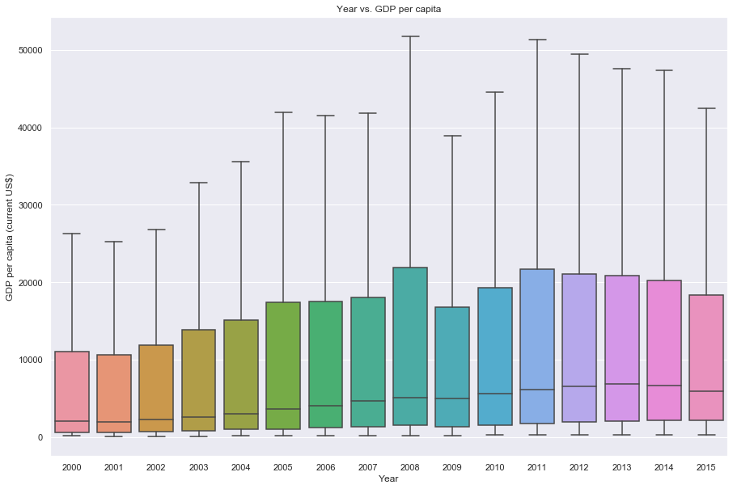

```python
sns.set(rc={'figure.figsize':(15,10)})
box = sns.boxplot(x="Year", y="GDP per capita (current US$)", data=predictionData, showfliers=False).set_title("Year vs. GDP per capita")
```

The box plot below has shown how GDP and GDP per capita has grown throughout the years. As you can see there is a large drop in 2009 due to the great recession. Otherwise GDP growth has stayed very consistent in terms of growth throughout the years.

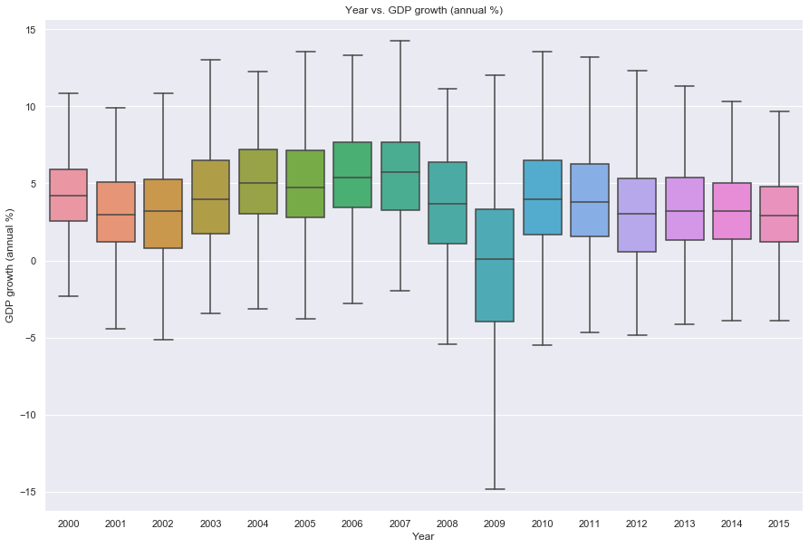

```python
sns.set(rc={'figure.figsize':(15,10)})
box = sns.boxplot(x="Year", y="GDP growth (annual %)", data=predictionData, showfliers=False).set_title("Year vs. GDP growth (annual %)")
```

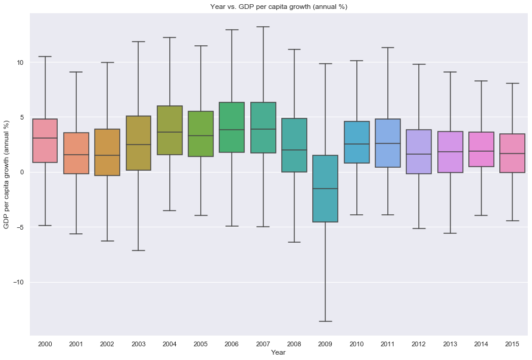

```python
sns.set(rc={'figure.figsize':(15,10)})
box = sns.boxplot(x="Year", y="GDP per capita growth (annual %)", data=predictionData, showfliers=False).set_title("Year vs. GDP per capita growth (annual %)")
```

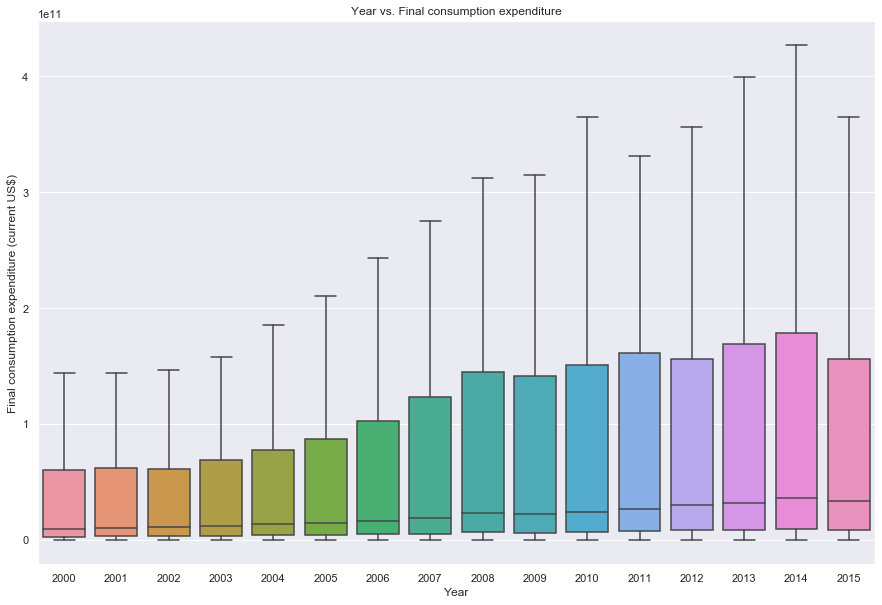

```python
sns.set(rc={'figure.figsize':(15,10)})
box = sns.boxplot(x="Year", y="Final consumption expenditure (current US$)", data=predictionData, showfliers=False).set_title("Year vs. Final consumption expenditure")
```

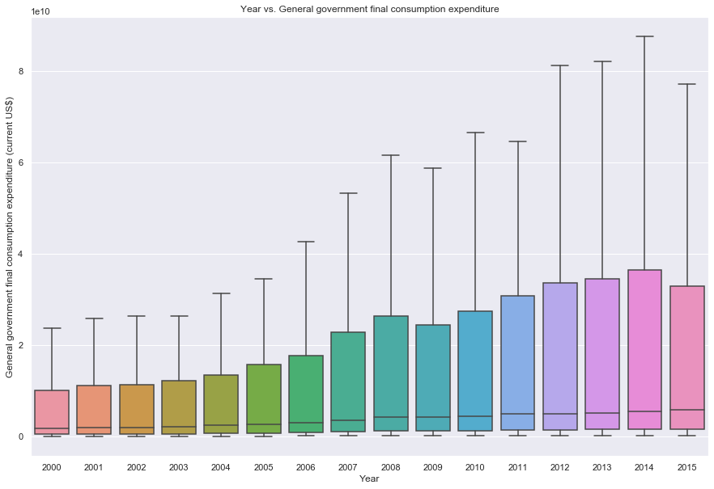

```python
sns.set(rc={'figure.figsize':(15,10)})
box = sns.boxplot(x="Year", y="General government final consumption expenditure (current US$)", data=predictionData, showfliers=False).set_title("Year vs. General government final consumption expenditure")
```

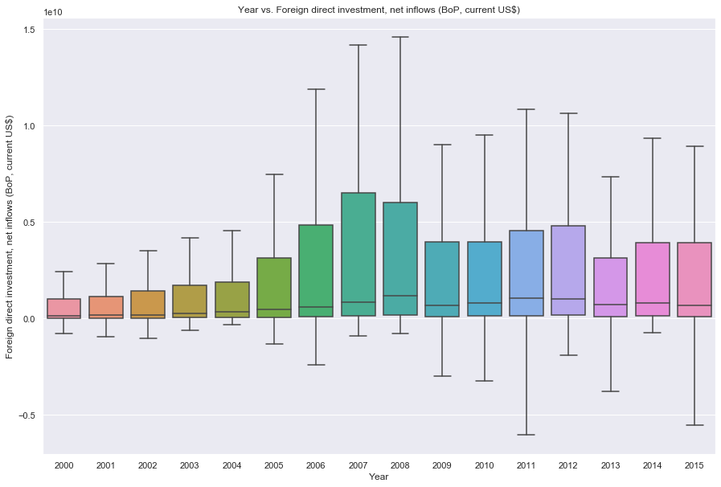

```python
sns.set(rc={'figure.figsize':(15,10)})
box = sns.boxplot(x="Year", y="Foreign direct investment, net inflows (BoP, current US$)", data=predictionData, showfliers=False).set_title("Year vs. Foreign direct investment, net inflows (BoP, current US$)")
```

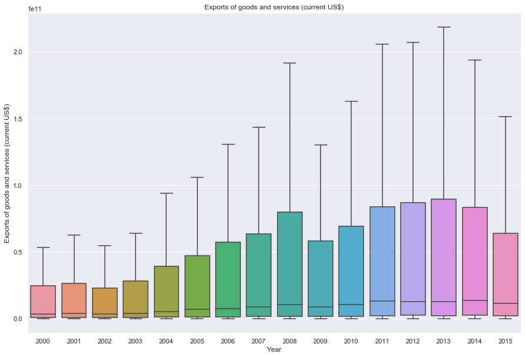

```python
sns.set(rc={'figure.figsize':(15,10)})
box = sns.boxplot(x="Year", y="Exports of goods and services (current US$)", data=predictionData, showfliers=False).set_title("Exports of goods and services (current US$)")
```

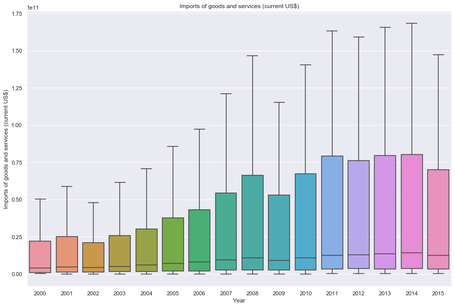

```python
sns.set(rc={'figure.figsize':(15,10)})
box = sns.boxplot(x="Year", y="Imports of goods and services (current US$)", data=predictionData, showfliers=False).set_title("Imports of goods and services (current US$)")
```

### 3.2 Observations from GDP Data

```python
richvsPoor = pd.DataFrame(columns = ["Country Name", "Year"])

countriesList = worldData["Country Name"]
for name in countriesList.unique():
    counter = 2000
    while counter <= 2015:
        richvsPoor = richvsPoor.append({"Country Name": name, "Year": counter}, ignore_index=True)
        counter += 1

richvsPoor["GDP growth (annual %)"] = 0.0

country = "Afghanistan"
countryCounter = 0
for index, row in worldData.iterrows():
    if row["Country Name"] != country:
        countryCounter += 1
        country = row["Country Name"]
    if row["Series Name"] in richvsPoor.columns:
        counter = 2000
        while counter <= 2015:
            yearString = str(counter) + " [YR" + str(counter) + "]"
            indx = countryCounter * 16 + (counter - 2000)
            if row[yearString] != "..":
                richvsPoor.at[indx, row["Series Name"]] = row[yearString]
            else:
                richvsPoor.at[indx, row["Series Name"]] = np.nan
            counter += 1

graphData = pd.DataFrame(columns=richvsPoor.columns)
graphData2 = pd.DataFrame(columns=richvsPoor.columns)
richvsPoor.drop(richvsPoor.index[:3696], inplace=True)
for index, row in richvsPoor.iterrows():
    if row["Country Name"] == "Least developed countries: UN classification":
        graphData = graphData.append(row, ignore_index=True)
    elif row["Country Name"] == "High income":
        graphData2 = graphData2.append(row, ignore_index=True)
```

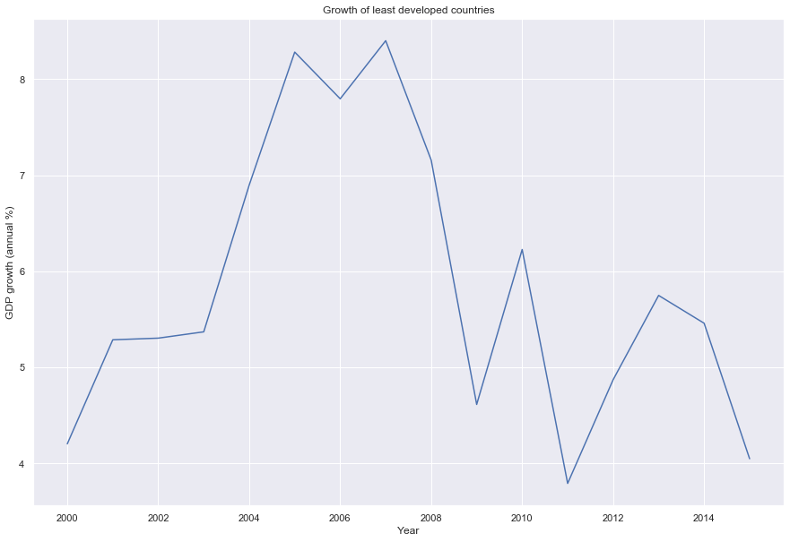

```python
sns.set(rc={'figure.figsize':(15,10)})
box = sns.lineplot(x="Year", y="GDP growth (annual %)", data=graphData).set_title("Growth of least developed countries")
```

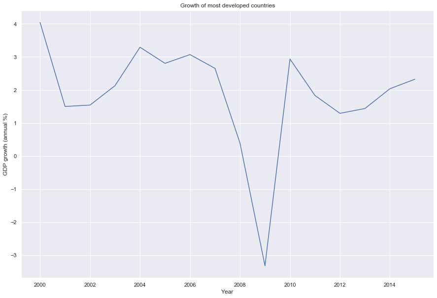

```python
sns.set(rc={'figure.figsize':(15,10)})
box = sns.lineplot(x="Year", y="GDP growth (annual %)", data=graphData2).set_title("Growth of most developed countries")
```

This is due in part because of the solow model. According to the [University of Pittsburgh](https://www.pitt.edu/~mgahagan/Solow.htm).

“If the Solow model is correct, and if growth is due to capital accumulation , we should expect to find

Growth will be very strong when countries first begin to accumulate capital, and will slow down as the process of accumulation continues. Japanese growth was stronger in the 1950s and 1960s than it is now. Countries will tend to converge in output per capita and in standard of living. As Hong Kong, Singapore, Taiwan (etc) accumulate capital, their standard of living will catch up with the initially more developed countries. When all countries have reached a steady state, all countries will have the same standard of living (at least if they have the same production function, which for most industrial goods is a reasonable assumption).”

This model helps explain why poorer countries are growing their economies at a faster rate than their developed nations. Of course there are always exceptions and in some cases developed countries grow faster than developing ones, but the general trend still exists.

### 3.3 Miscellaneous Joint Plots

The following table below provides us with the statistics from the miscellaneous variables that we thought would correlate to GDP.

```python
miscellaneousData.describe()
```

|  | GDP per capita (current US$) | Employment in agriculture (% of total employment) (modeled ILO estimate) | Employment in industry (% of total employment) (modeled ILO estimate) | Employment in services (% of total employment) (modeled ILO estimate) | Current health expenditure (% of GDP) | Fertility rate, total (births per woman) | Government expenditure on education, total (% of GDP) | Prevalence of undernourishment (% of population) | Adjusted net enrollment rate, primary (% of primary school age children) |
| --- | --- | --- | --- | --- | --- | --- | --- | --- | --- |
| count | 3990.000000 | 3712.000000 | 3712.000000 | 3712.000000 | 3704.000000 | 3937.000000 | 1871.000000 | 3324.000000 | 2424.000000 |
| mean | 12840.332986 | 30.099654 | 19.810493 | 50.089872 | 6.171237 | 2.978158 | 4.503243 | 12.784069 | 89.892001 |
| std | 20578.005360 | 23.758027 | 7.912705 | 18.568244 | 2.789795 | 1.517292 | 1.816796 | 11.509354 | 12.185349 |
| min | 111.927224 | 0.180000 | 2.051000 | 5.377000 | 1.024978 | 0.860000 | 0.787440 | 2.500000 | 26.895430 |
| 25% | 1272.155890 | 7.963750 | 14.136000 | 35.154501 | 4.346333 | 1.800000 | 3.216830 | 3.000000 | 87.166593 |
| 50% | 4152.963263 | 25.051000 | 20.727506 | 51.589001 | 5.509363 | 2.482996 | 4.363220 | 9.000000 | 94.810600 |
| 75% | 15141.364903 | 48.155857 | 25.010750 | 65.353114 | 7.719829 | 4.007000 | 5.490590 | 18.755584 | 97.795216 |
| max | 189170.895671 | 92.547997 | 59.576000 | 87.990997 | 27.417822 | 7.679000 | 18.161070 | 71.500000 | 100.000000 |

To illustrate the relationship between the miscellaneous variables and GDP per capita, we used joint plots, which are a combination of one scatter plot representing the correlation and two bar plots representing the Gaussian distribution of each of the variables respectively. The joint plots show correlation between several key data points and the GDP per capita of countries.

Employment in Agriculture vs GDP per capita

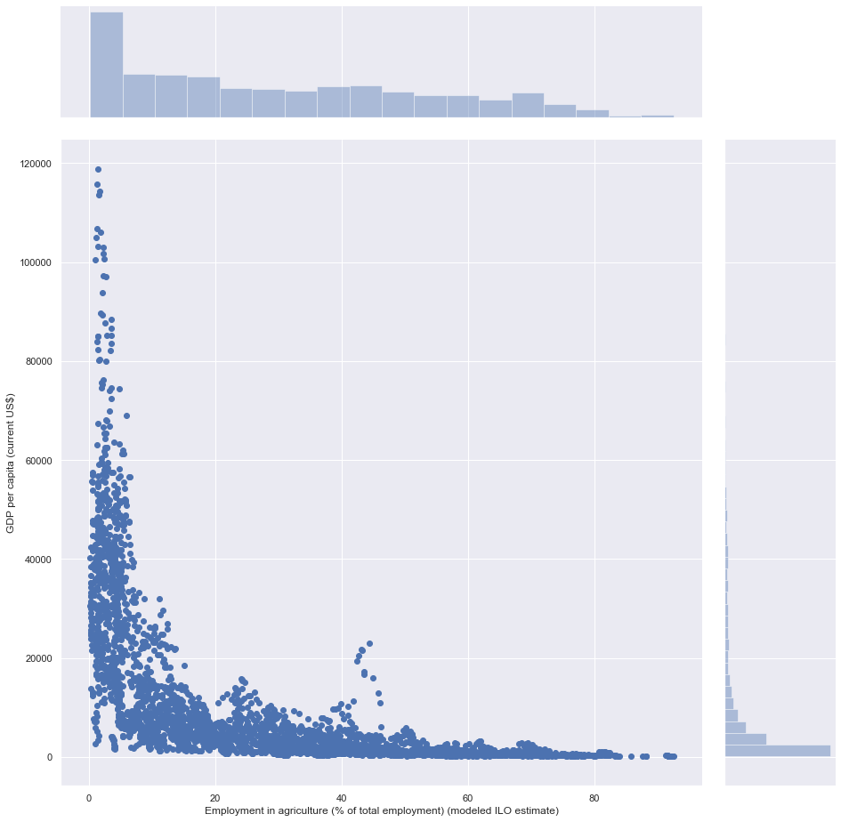

```python
sns.set(rc={'figure.figsize':(15,10)})
joint = sns.jointplot(x="Employment in agriculture (% of total employment) (modeled ILO estimate)", y="GDP per capita (current US$)", data=miscellaneousData, height = 13)
```

Employment in Industry vs GDP per capita

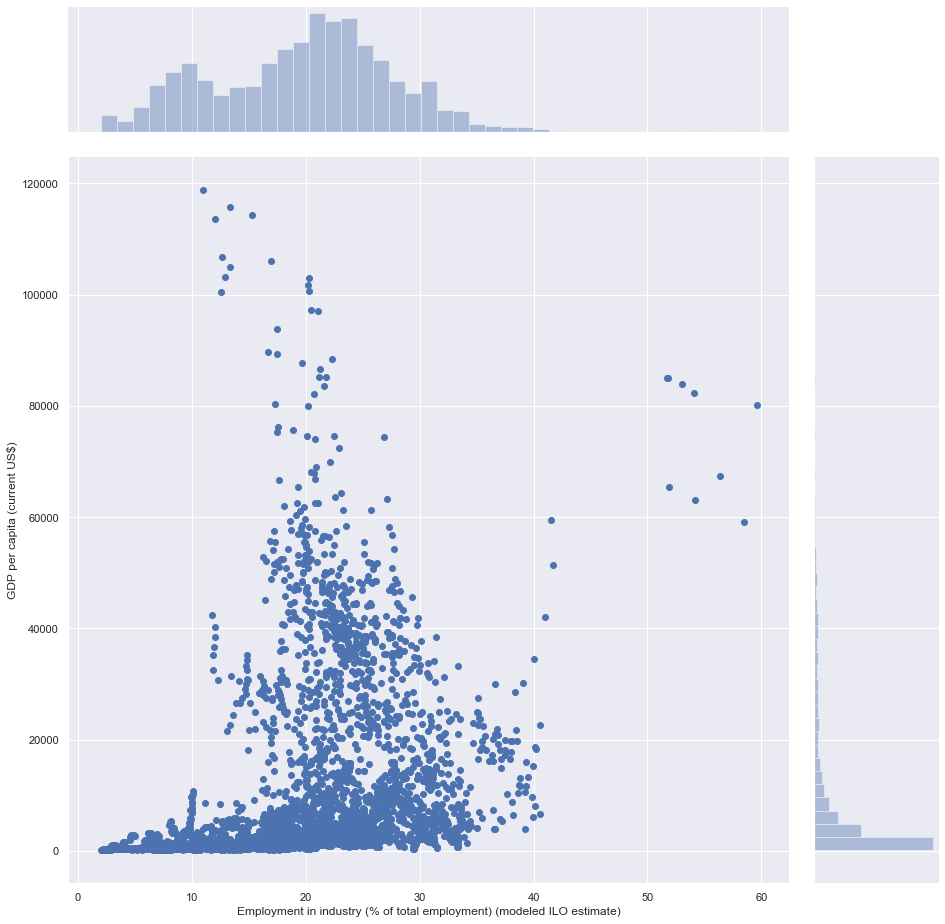

```python
sns.set(rc={'figure.figsize':(15,10)})
joint = sns.jointplot(x="Employment in industry (% of total employment) (modeled ILO estimate)", y="GDP per capita (current US$)", data=miscellaneousData, height = 13)
```

Employment in Services vs GDP per capita

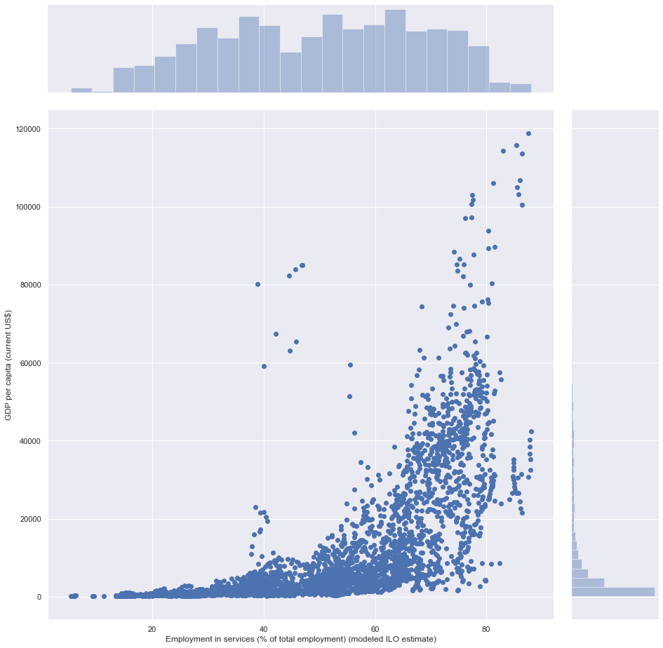

```python
sns.set(rc={'figure.figsize':(15,10)})
joint = sns.jointplot(x="Employment in services (% of total employment) (modeled ILO estimate)", y="GDP per capita (current US$)", data=miscellaneousData, height = 13)
```

Current Health Expenditure vs GDP per capita

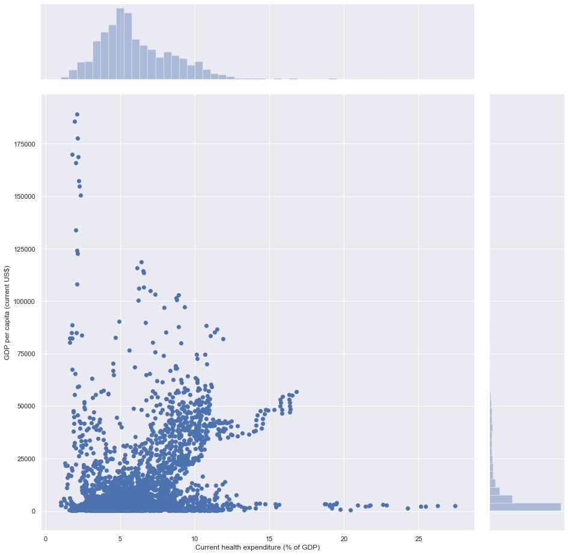

```python
sns.set(rc={'figure.figsize':(15,10)})
joint = sns.jointplot(x="Current health expenditure (% of GDP)", y="GDP per capita (current US$)", data=miscellaneousData, height = 13)
```

Fertility Rate vs GDP per capita

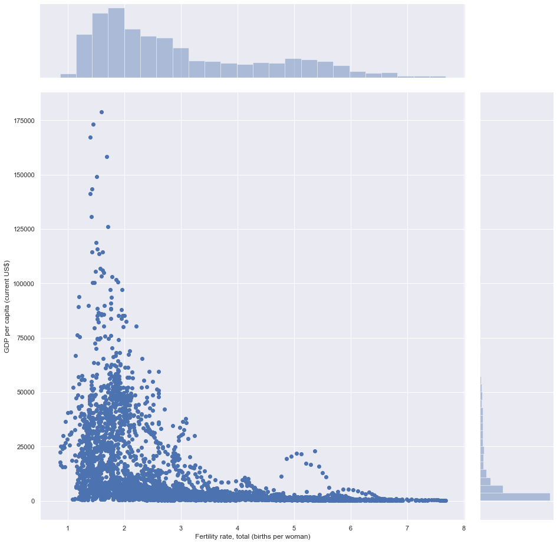

```python
sns.set(rc={'figure.figsize':(15,10)})
joint = sns.jointplot(x="Fertility rate, total (births per woman)", y="GDP per capita (current US$)", data=miscellaneousData, height = 13)
```

Prevalence of Undernourishment vs GDP per capita

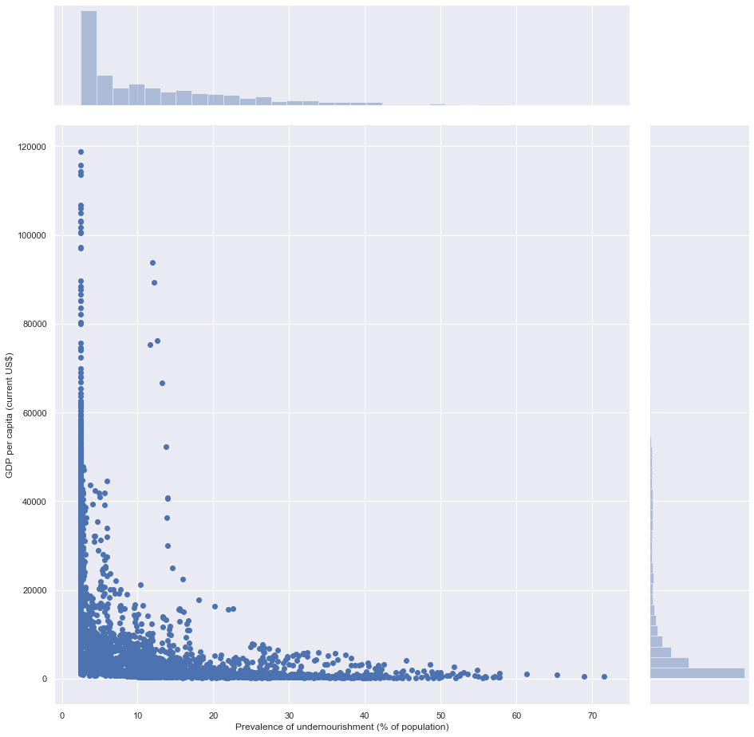

```python
sns.set(rc={'figure.figsize':(15,10)})
joint = sns.jointplot(x="Prevalence of undernourishment (% of population)", y="GDP per capita (current US$)", data=miscellaneousData, height = 13)
```

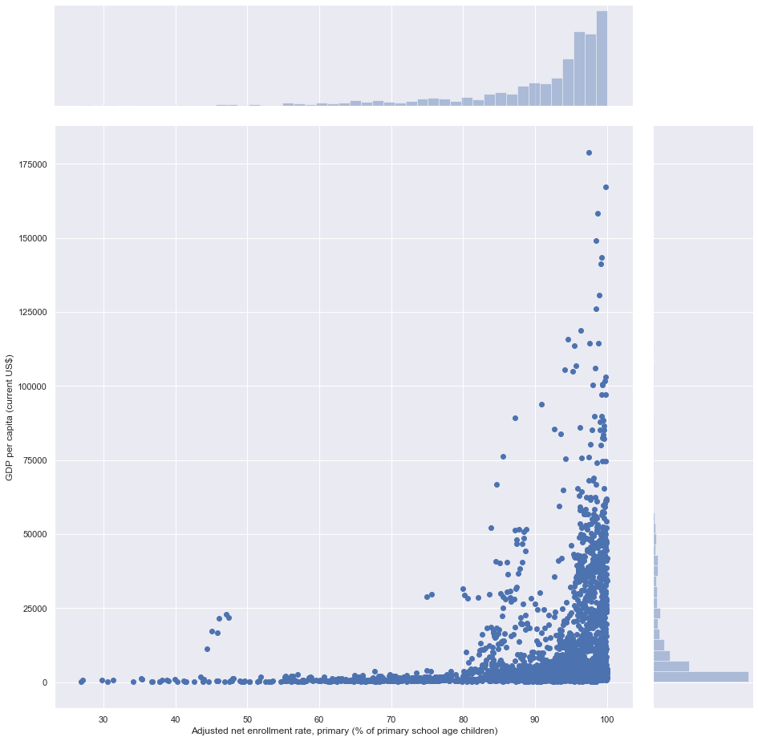

```python
sns.set(rc={'figure.figsize':(15,10)})
joint = sns.jointplot(x="Adjusted net enrollment rate, primary (% of primary school age children)", y="GDP per capita (current US$)", data=miscellaneousData, height = 13)
```

### 3.4 Observations from Miscellaneous Data

There are some obvious correlations between GDP per capita and data points such as undernourishment, primary school enrollment, and the fertility rate. But there were also a couple of interesting caveats that were less obvious. For example, nations that had low GDP per capitas tended to have high percentages of its workforce in the agricultural industry. Also nations that had high GDP per capitas tended to have high percentages of its workforce in the service industry. But there was a healthy mix of economies when it came to high percentages of their workforce in industry. Some nations with high industry employment came from relatively rich countries and some places from very poor nations had high levels of employment in industry. The general trend was still that developing nations with their GDP per capitas near the average tended to have the most concentration on industry work. Also nations that tended to spend more of their % of GDP on healthcare tended to be richer nations rather than poorer ones, although the correlation for that data point was not as strong.

## Analysis, Hypothesis Testing, and Machine Learning

### 4.0 Linear Regression

For the analysis, hypothesis testing, and machine learning part of this tutorial, we will be performing linear regression to model our data and thus better observe how different factors influence GDP.

To do so, we must organize the data used for the box plots (predictionData) from earlier since we will be first do linear regressions on GDP per capita, final consumption expenditure, general government final consumption expenditure, foreign direct investment, exports and imports of goods and services. We do this by copying predictionData into a separate dataframe, dropping irrelevant columns including CountryName, and grouping the data by year such that we get the mean for GDP per capita, final consumption expenditure, general government final consumption expenditure, foreign direct investment, exports and imports of goods and services for each year.

```python
linearData = predictionData.copy()

linearData = linearData.drop(columns=['Country Name', 'GDP per capita growth (annual %)', 'Final consumption expenditure (% of GDP)', 'General government final consumption expenditure (% of GDP)', 'Foreign direct investment, net inflows (% of GDP)', 'Exports of goods and services (% of GDP)', 'Imports of goods and services (% of GDP)' , 'GDP growth (annual %)'])
linearData = linearData.groupby(['Year']).mean()

linearData
```

| Year | GDP per capita (current US$) | Final consumption expenditure (current US$) | General government final consumption expenditure (current US$) | Foreign direct investment, net inflows (BoP, current US$) | Exports of goods and services (current US$) | Imports of goods and services (current US$) |
| --- | --- | --- | --- | --- | --- | --- |
| 2000 | 8262.088508 | 1.535055e+11 | 3.249478e+10 | 7.806785e+09 | 4.360903e+10 | 4.357668e+10 |
| 2001 | 8177.092747 | 1.540718e+11 | 3.292009e+10 | 4.186021e+09 | 4.265312e+10 | 4.278136e+10 |
| 2002 | 8835.874793 | 1.589575e+11 | 3.437985e+10 | 3.859754e+09 | 4.307683e+10 | 4.277253e+10 |
| 2003 | 10172.606619 | 1.770522e+11 | 3.897877e+10 | 3.787026e+09 | 4.977109e+10 | 4.940153e+10 |
| 2004 | 11533.833415 | 1.950024e+11 | 4.307976e+10 | 5.120561e+09 | 5.965168e+10 | 5.896791e+10 |
| 2005 | 12644.269814 | 2.085911e+11 | 4.600748e+10 | 7.838510e+09 | 6.799933e+10 | 6.709944e+10 |
| 2006 | 13898.218389 | 2.210146e+11 | 4.910813e+10 | 1.115341e+10 | 7.732686e+10 | 7.580359e+10 |
| 2007 | 15440.620704 | 2.456418e+11 | 5.476545e+10 | 1.575084e+10 | 8.954344e+10 | 8.753747e+10 |
| 2008 | 16636.599187 | 2.696049e+11 | 6.173632e+10 | 1.239386e+10 | 1.023520e+11 | 1.003934e+11 |
| 2009 | 14763.123772 | 2.612132e+11 | 6.192258e+10 | 7.019040e+09 | 8.203603e+10 | 8.021667e+10 |
| 2010 | 15492.676635 | 2.785346e+11 | 6.505276e+10 | 9.477995e+09 | 9.756029e+10 | 9.483471e+10 |
| 2011 | 17073.803772 | 3.044211e+11 | 7.058089e+10 | 1.174635e+10 | 1.154020e+11 | 1.121817e+11 |
| 2012 | 16968.367601 | 3.121093e+11 | 7.164700e+10 | 1.025617e+10 | 1.173145e+11 | 1.137774e+11 |
| 2013 | 17555.761424 | 3.189568e+11 | 7.248834e+10 | 1.080568e+10 | 1.193131e+11 | 1.157870e+11 |
| 2014 | 17524.352978 | 3.289834e+11 | 7.396878e+10 | 9.370995e+09 | 1.219400e+11 | 1.189207e+11 |
| 2015 | 15729.256623 | 3.149450e+11 | 7.010390e+10 | 1.324258e+10 | 1.100418e+11 | 1.074029e+11 |

Now, we may perform linear regression on GDP per capita (current USD) over time by creating a scatter plot containing years on the x-axis and GDP per capita (current USD) on the y-axis and then fitting a best fit line using LinearRegression() over the scatter plot.

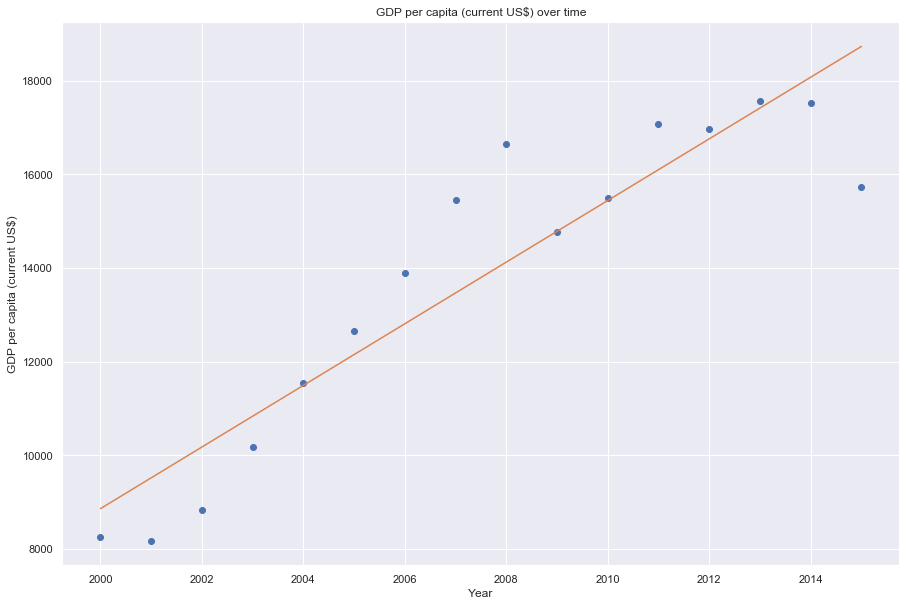

```python
text = "GDP per capita (current US$)"

years = []
GDP_per_capita = []
for index, row in linearData.iterrows():
    years.append(index)
    GDP_per_capita.append(row[0])

plt.plot(years,GDP_per_capita,'o')


years_ = []
for y in years:
    years_.append([y])


clf = linear_model.LinearRegression()
clf.fit(years_,GDP_per_capita)
predicted = clf.predict(years_)

plt.plot(years,predicted)
plt.title("{} over time".format(text))
plt.xlabel("Year")
plt.ylabel("GDP per capita (current US$)")
plt.show()
```

In the resulting plot, we can clearly see a positive trend from just the scatter plot alone, and the linear model confirms this since it produces a linear line with a positive slope. Thus, we can confirm that GDP per capita grows over time.

Next, we will find the R^2 value to see how well the linear regression fits our data by using clf.score().

```python
print(clf.score(years_,GDP_per_capita))
```

```
0.8481106413800102
```

Our results show R^2 being 0.848 which means that the linear regression fits the data pretty well as it is closer to 1 which signifies a perfect fit than 0 which means no meaningful fit.

Moving on, we must observe the fact that our scatter plot seems to flatten after 2010, so we must see if a polynomial of 2 degrees fits our data better.

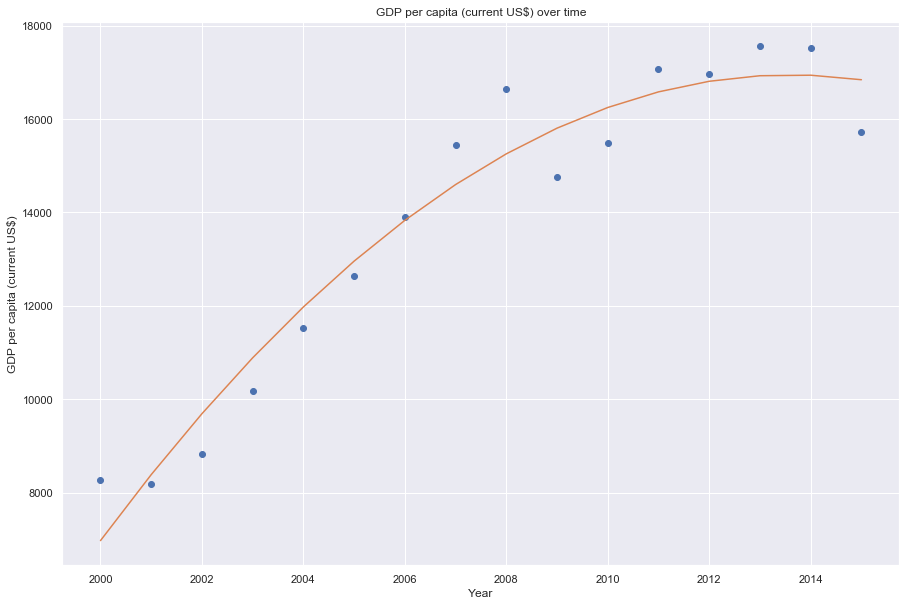

```
0.9437415420076714
```

```python
plt.plot(years,GDP_per_capita,'o')

polynomial_Feats = PolynomialFeatures(degree=2)
polynomial_years = polynomial_Feats.fit_transform(years_)
clf.fit(polynomial_years,GDP_per_capita)

polynomial_predict = clf.predict(polynomial_years)
plt.title("{} over time".format(text))
plt.xlabel("Year")
plt.ylabel("GDP per capita (current US$)")
plt.plot(years,polynomial_predict)

plt.show()
print(clf.score(polynomial_years,GDP_per_capita))
```

Here we have a R^2 value of 0.944 which is much better than our linear fit.

Now we can try a polynomial with 3 degrees.

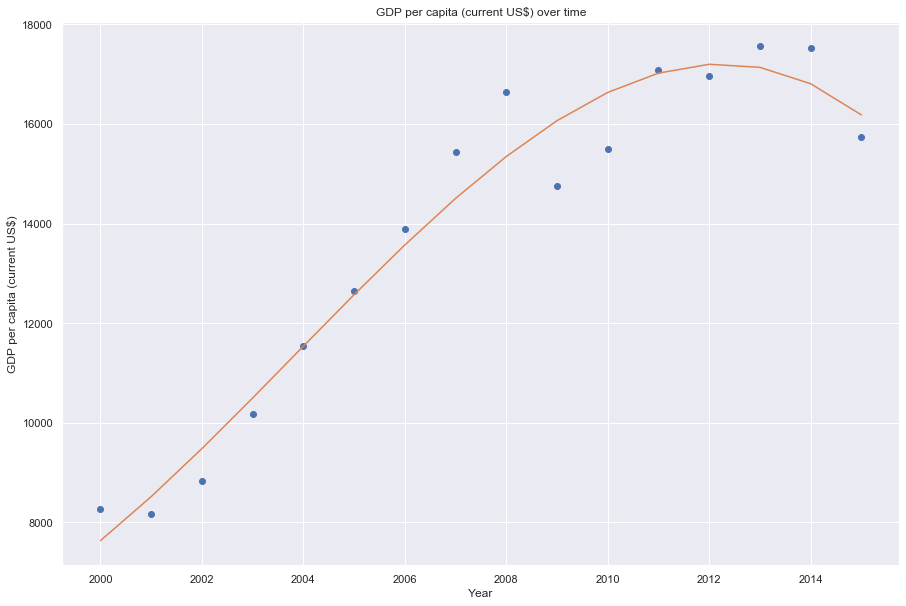

```
0.9560257134769029
```

```python
plt.plot(years,GDP_per_capita,'o')

polynomial_Feats = PolynomialFeatures(degree=3)
polynomial_years = polynomial_Feats.fit_transform(years_)
clf.fit(polynomial_years,GDP_per_capita)

polynomial_predict = clf.predict(polynomial_years)
plt.title("{} over time".format(text))
plt.xlabel("Year")
plt.ylabel("GDP per capita (current US$)")
plt.plot(years,polynomial_predict)

plt.show()
print(clf.score(polynomial_years,GDP_per_capita))
```

Now we have an R^2 value of 0.956 which is slightly better than the last. However, must must take into account that the curve downwards seems to be heavily influenced by one data point on the scatter plot.

Next, we can repeat the process of fitting linear regressions to final consumption expenditure, general government final consumption expenditure, foreign direct investment, exports and imports of goods and services.

```python
def plot_GDP_predictors(x,y,linearData):
    years = []
    GDP_predictor = []
    for index, row in linearData.iterrows():
        years.append(index)
        GDP_predictor.append(row[y])

    plt.plot(years,GDP_predictor,'o')


    years_ = []
    for y in years:
        years_.append([y])

    clf = linear_model.LinearRegression()
    clf.fit(years_,GDP_predictor)
    predicted = clf.predict(years_)

    plt.title("{} over time".format(x))
    plt.xlabel("Year")
    plt.ylabel(x)

    r_squared = clf.score(years_,GDP_predictor)
    plt.plot(years,predicted,label="linear-regression R^2:{}".format(round(r_squared,2)))
    plt.legend()
    plt.show()

    plt.plot(years,GDP_predictor,'o')

    polynomial_Feats = PolynomialFeatures(degree=2)
    polynomial_years = polynomial_Feats.fit_transform(years_)
    clf.fit(polynomial_years,GDP_predictor)

    polynomial_predict = clf.predict(polynomial_years)
    plt.title("{} over time".format(x))
    plt.xlabel("Year")
    plt.ylabel(x)
    plt.plot(years,polynomial_predict)

    plt.show()
    print(clf.score(polynomial_years,GDP_predictor))

    polynomial_Feats = PolynomialFeatures(degree=3)
    polynomial_years = polynomial_Feats.fit_transform(years_)
    clf.fit(polynomial_years,GDP_predictor)

    polynomial_predict = clf.predict(polynomial_years)
    plt.title("{} over time".format(x))
    plt.xlabel("Year")
    plt.ylabel(x)
    plt.plot(years,polynomial_predict)

    plt.show()
    print(clf.score(polynomial_years,GDP_predictor))
```

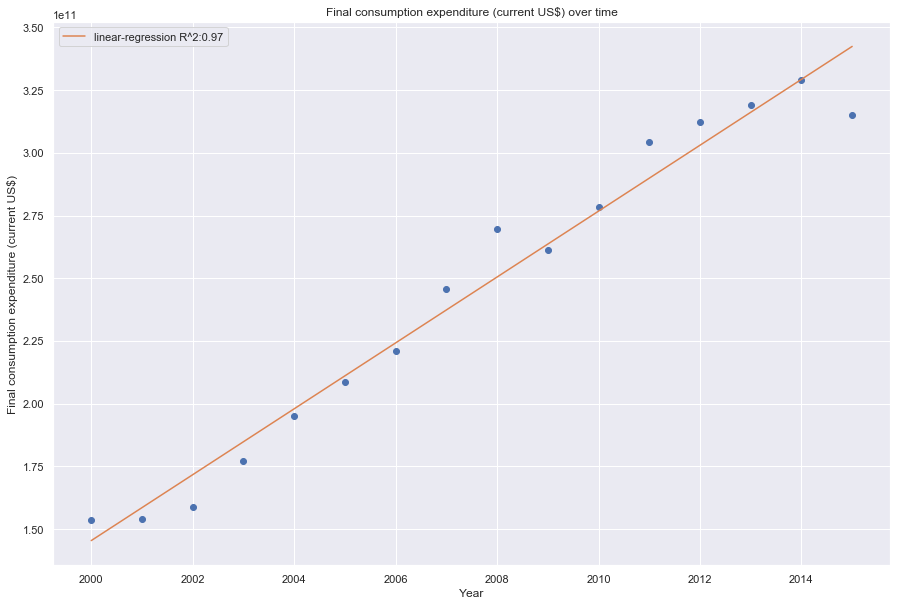

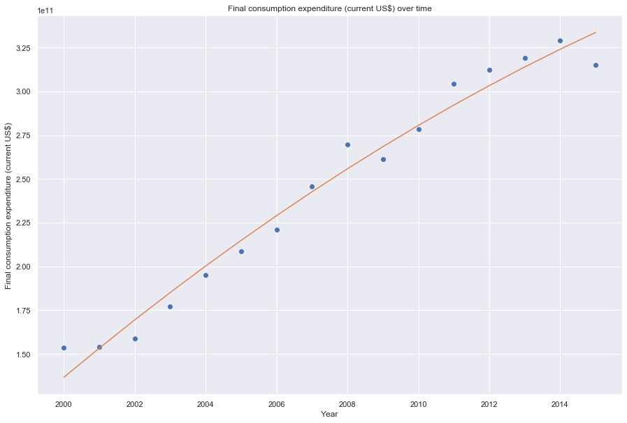

```
0.9756333475823485
```

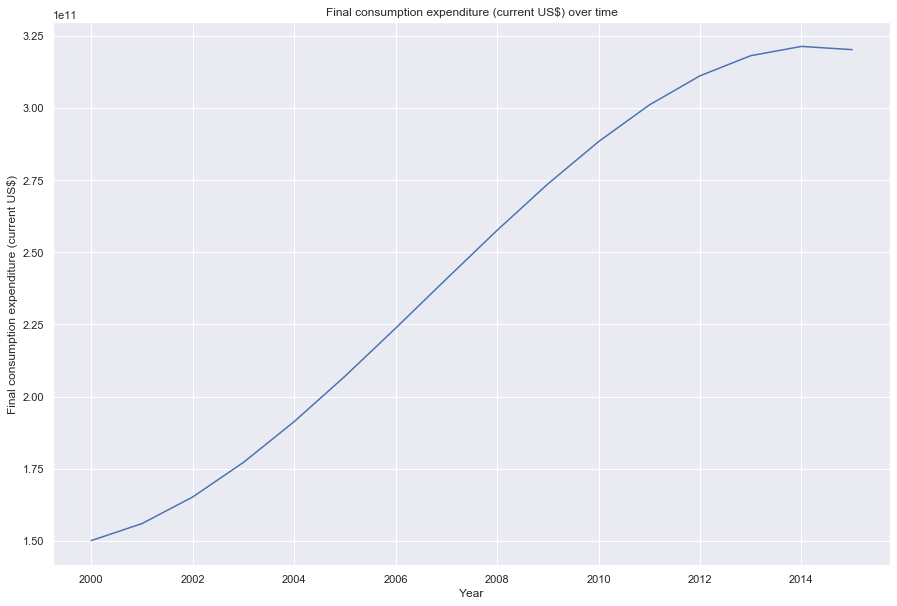

```
0.9901472894559978
```

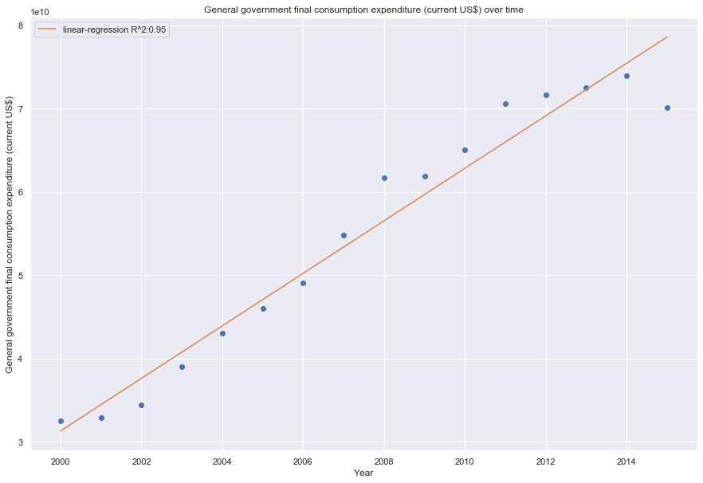

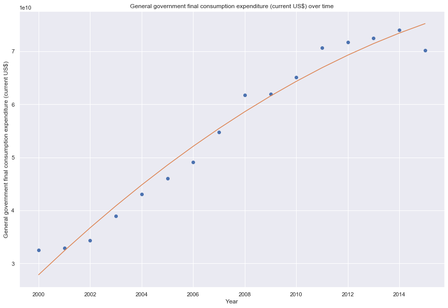

```
0.9698707926452302
```

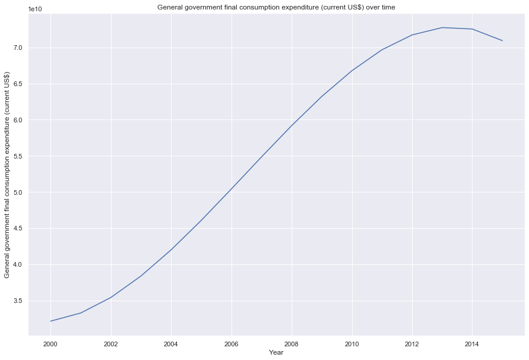

```
0.9945338591617091
```

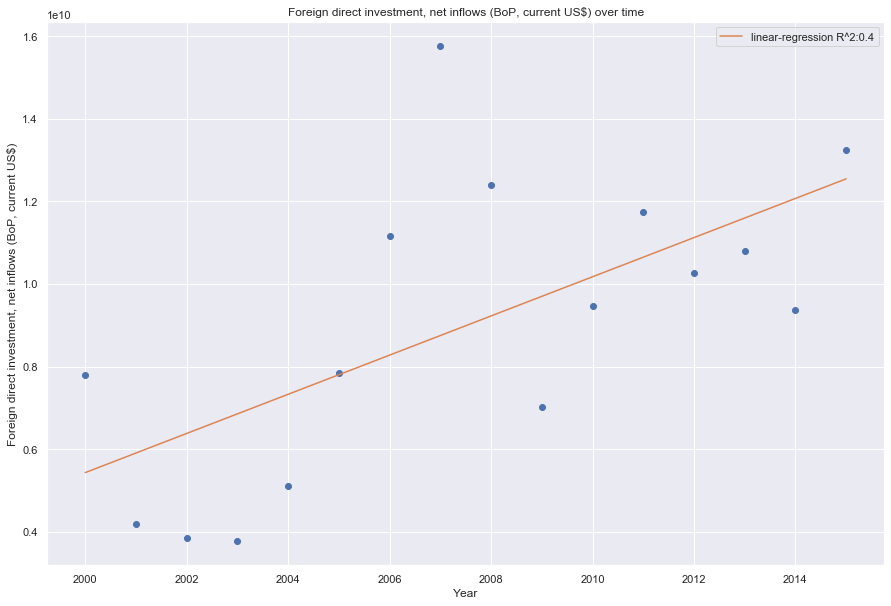

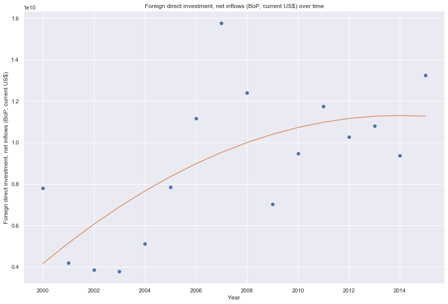

```
0.4399749833373702
```

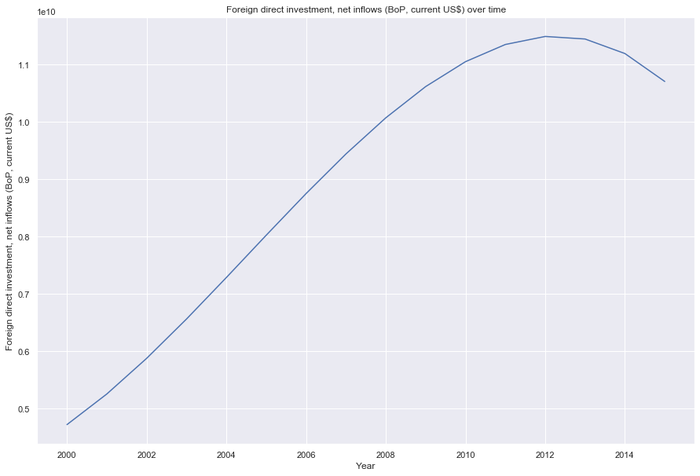

```
0.4481278754534001
```

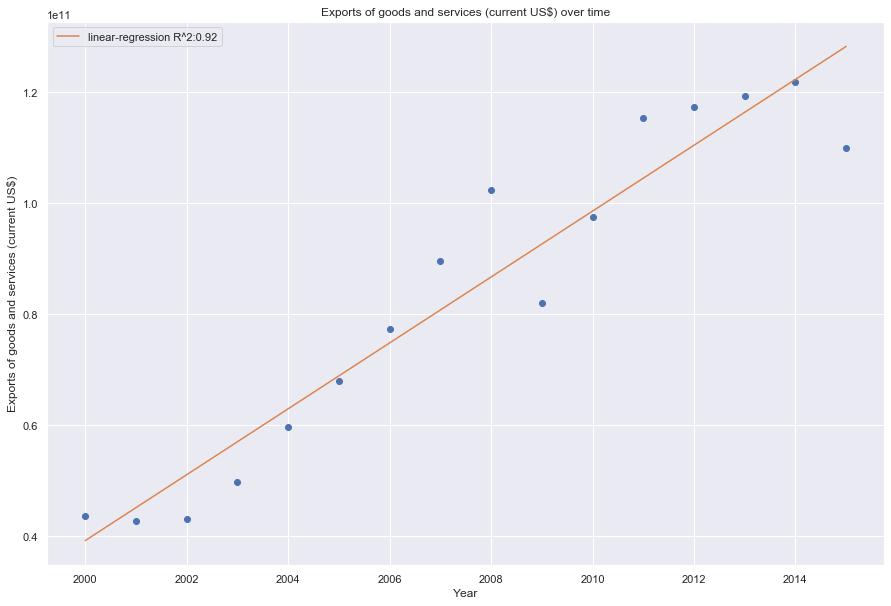

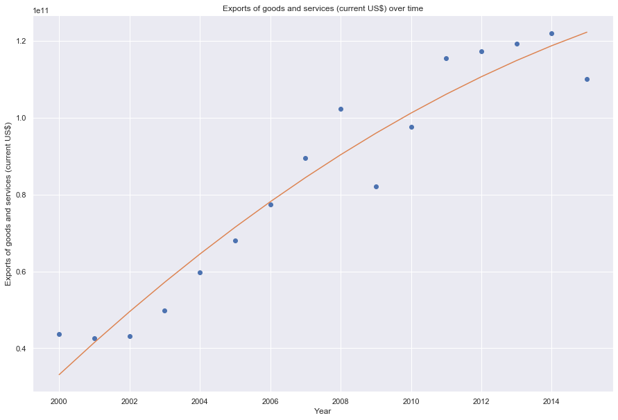

```
0.9289064425890834
```

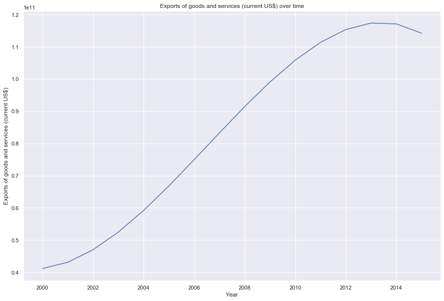

```
0.9528024570920761
```

[3 more figures not shown]

```
0.9507969423864838
```

```python
plot_GDP_predictors("Final consumption expenditure (current US$)",1,linearData)
plot_GDP_predictors("General government final consumption expenditure (current US$)",2,linearData)
plot_GDP_predictors("Foreign direct investment, net inflows (BoP, current US$)",3,linearData)
plot_GDP_predictors("Exports of goods and services (current US$)",4,linearData)
plot_GDP_predictors("Imports of goods and services (current US$)",5,linearData)
```

Our results show that final consumption expenditure, general government final consumption expenditure, foreign direct investment net inflows, exports and imports of goods and services all trend upwards, but it is important to note that the R^2 value for foreign direct investment, net inflows is sub 0.5

Next, we can repeat the same process for linear regression with our data from miscelleaneousData.

```python
linearmiscData = miscellaneousData.copy()

linearmiscData = linearmiscData.drop(columns=['Country Name'])
linearmiscData = linearmiscData.groupby(['Year']).mean()

linearmiscData
```

| Year | GDP per capita (current US$) | Employment in agriculture (% of total employment) (modeled ILO estimate) | Employment in industry (% of total employment) (modeled ILO estimate) | Employment in services (% of total employment) (modeled ILO estimate) | Current health expenditure (% of GDP) | Fertility rate, total (births per woman) | Government expenditure on education, total (% of GDP) | Prevalence of undernourishment (% of population) | Adjusted net enrollment rate, primary (% of primary school age children) |
| --- | --- | --- | --- | --- | --- | --- | --- | --- | --- |
| 2000 | 7674.059169 | 33.266764 | 19.793678 | 46.939581 | 5.669040 | 3.236639 | 4.331777 | 15.608488 | 86.229305 |
| 2001 | 7601.921824 | 32.926700 | 19.719297 | 47.354022 | 5.794969 | 3.179547 | 4.583330 | 15.163513 | 87.836950 |
| 2002 | 8187.985866 | 32.584507 | 19.628847 | 47.786637 | 5.849889 | 3.128455 | 4.607709 | 14.801800 | 88.548263 |
| 2003 | 9406.302141 | 32.208138 | 19.612557 | 48.179314 | 5.982862 | 3.098433 | 4.614258 | 14.414298 | 88.443202 |
| 2004 | 10662.460932 | 31.692356 | 19.725695 | 48.581966 | 6.049743 | 3.074591 | 4.283678 | 14.001038 | 89.189588 |
| 2005 | 11680.119174 | 31.291222 | 19.779725 | 48.929095 | 6.078361 | 3.043457 | 4.455298 | 13.548731 | 89.657071 |
| 2006 | 12821.145539 | 30.756350 | 19.936304 | 49.307399 | 6.068830 | 3.010137 | 4.372100 | 13.016966 | 89.568532 |
| 2007 | 14274.433976 | 30.206053 | 20.119412 | 49.674539 | 6.069712 | 2.984493 | 4.405553 | 12.612164 | 90.196741 |
| 2008 | 15415.637317 | 29.806488 | 20.141725 | 50.051844 | 6.071279 | 2.962120 | 4.496413 | 12.255640 | 90.401707 |
| 2009 | 13726.989250 | 29.397005 | 19.778971 | 50.824109 | 6.441899 | 2.931903 | 4.798666 | 11.908968 | 90.550490 |
| 2010 | 14443.165491 | 28.962893 | 19.776857 | 51.260184 | 6.383492 | 2.906781 | 4.597329 | 11.582867 | 90.931575 |
| 2011 | 15925.555971 | 28.567611 | 19.812458 | 51.619952 | 6.301643 | 2.878981 | 4.314016 | 11.294691 | 90.525424 |
| 2012 | 15843.598688 | 28.079389 | 19.768557 | 52.152043 | 6.326390 | 2.844951 | 4.379606 | 11.235379 | 91.616897 |
| 2013 | 16376.861945 | 27.709204 | 19.727247 | 52.563575 | 6.435365 | 2.817140 | 4.502918 | 11.115239 | 91.031555 |
| 2014 | 16377.904435 | 27.263746 | 19.812731 | 52.923552 | 6.540891 | 2.794485 | 4.597896 | 11.059017 | 91.054105 |
| 2015 | 14725.161619 | 26.876034 | 19.833833 | 53.290137 | 6.666070 | 2.760563 | 4.721180 | 11.094242 | 90.788136 |

```python
def plot_GDP_misc(x,y,linearmiscData):
    years = []
    GDP_predictor = []
    for index, row in linearmiscData.iterrows():
        years.append(index)
        GDP_predictor.append(row[y])

    plt.plot(years,GDP_predictor,'o')


    years_ = []
    for y in years:
        years_.append([y])

    clf = linear_model.LinearRegression()
    clf.fit(years_,GDP_predictor)
    predicted = clf.predict(years_)

    plt.title("{} over time".format(x))
    plt.xlabel("Year")
    plt.ylabel(x)

    r_squared = clf.score(years_,GDP_predictor)
    plt.plot(years,predicted,label="linear-regression R^2:{}".format(round(r_squared,2)))
    plt.legend()
    plt.show()

    plt.plot(years,GDP_predictor,'o')

    polynomial_Feats = PolynomialFeatures(degree=2)
    polynomial_years = polynomial_Feats.fit_transform(years_)
    clf.fit(polynomial_years,GDP_predictor)

    polynomial_predict = clf.predict(polynomial_years)
    plt.title("{} over time".format(x))
    plt.xlabel("Year")
    plt.ylabel(x)
    plt.plot(years,polynomial_predict)

    plt.show()
    print(clf.score(polynomial_years,GDP_predictor))

    polynomial_Feats = PolynomialFeatures(degree=3)
    polynomial_years = polynomial_Feats.fit_transform(years_)
    clf.fit(polynomial_years,GDP_predictor)

    polynomial_predict = clf.predict(polynomial_years)
    plt.title("{} over time".format(x))
    plt.xlabel("Year")
    plt.ylabel(x)
    plt.plot(years,polynomial_predict)

    plt.show()
    print(clf.score(polynomial_years,GDP_predictor))
```